# Pulvirenti-final

Before proceeding to the most interesting tasks, we should take care of the data, which are quite dirty

Let's import the required libraries, and then proceed to the first dataset

```python
import pandas as pd
import numpy as np
import matplotlib.pyplot as plt
import seaborn as sns
```

```python
Demographics = pd.read_csv('Model Build - Demographics.csv', header=0, encoding='ISO-8859-15')
```

```python
Demographics.head()
```

|  | Client ID | Age | Gender 1: Female, 2: Male | County | Income Group | Unnamed: 5 |
| --- | --- | --- | --- | --- | --- | --- |
| 0 | 1 | 36 | 1 | Cork | 10001 - 40000 | NaN |
| 1 | 2 | 43 | 1 | Cavan | 0 - 10000 | NaN |
| 2 | 3 | 32 | 0 | Dublin | 10001 - 40000 | NaN |
| 3 | 4 | 52 | 1 | Louth | 40001 - 60000 | NaN |
| 4 | 5 | 63 | 0 | Kilkenny | 60001 - 100000 | NaN |

There is an extra column (extra comma in the csv)

```python
Demographics = Demographics[Demographics.columns[:5]]
```

Don't like that (wrong) "Gender 1: Female, 2: Male"

```python
Demographics = Demographics.rename(columns={'Gender \n1: Female, 2: Male' : "Gender"})
Demographics.head()
```

|  | Client ID | Age | Gender | County | Income Group |
| --- | --- | --- | --- | --- | --- |
| 0 | 1 | 36 | 1 | Cork | 10001 - 40000 |
| 1 | 2 | 43 | 1 | Cavan | 0 - 10000 |
| 2 | 3 | 32 | 0 | Dublin | 10001 - 40000 |
| 3 | 4 | 52 | 1 | Louth | 40001 - 60000 |
| 4 | 5 | 63 | 0 | Kilkenny | 60001 - 100000 |

let's see if there are more entries for the same Client ID

```python
Demographics.groupby("Client ID").filter(lambda x: len(x) > 1)
```

|  | Client ID | Age | Gender | County | Income Group |
| --- | --- | --- | --- | --- | --- |
| 45 | 46 | 56 | 0 | Kerry | 10001 - 40000 |
| 46 | 46 | 20 | 0 | Laois | 10001 - 40000 |
| 1220 | 1220 | 67 | 0 | Tipperary | 10001 - 40000 |
| 1221 | 1220 | 48 | 1 | Kildare | 100000+ |
| 3675 | 3674 | 46 | 0 | Galway | 10001 - 40000 |
| 3676 | 3674 | 37 | 1 | Carlow | 10001 - 40000 |
| 3677 | 3675 | 56 | 1 | Dublin | 0 - 10000 |
| 3678 | 3675 | 23 | 1 | Cork | 10001 - 40000 |

Ok now we should think about these records. They could be meant as mistakes in the first immissions, with a failed attempt to overwrite. However, the same exacts tuples are found duplicated in the other datasets, so their data could easily be real. We do not to delete this customers from the db, let's assign them a new Client ID.

```python
Demographics.ix[46, "Client ID"] =  10001
Demographics.ix[1221, "Client ID"] =  10002
Demographics.ix[3676, "Client ID"] =  10003
Demographics.ix[3678, "Client ID"] =  10004
Demographics.groupby("Client ID").filter(lambda x: len(x) > 1)
```

|  | Client ID | Age | Gender | County | Income Group |
| --- | --- | --- | --- | --- | --- |

Focus on Gender

```python
Demographics.Gender.unique()
```

```
array([u'1', u'0', u'M', u'Male', u'f', u'fem', u'm', u'female'], dtype=object)
```

a lot of values (the funny thing is that none of them is 2 as in the column description) Let's fix this

```python
def gender (x):
    """Uniform the gender feature"""
    if ((x == '0') or (x == 'f') or (x == 'female') or (x == 'fem')):
        return 0
    else:
        return 1

Demographics['Gender'] = map (lambda x: gender(x), Demographics['Gender'])
Demographics.Gender.unique()
```

```
array([1, 0], dtype=int64)
```

```python
Demographics.describe()
```

|  | Client ID | Age | Gender |
| --- | --- | --- | --- |
| count | 10004.00000 | 10004.000000 | 10004.000000 |
| mean | 5002.50000 | 44.392043 | 0.509096 |
| std | 2888.05038 | 15.202030 | 0.499942 |
| min | 1.00000 | 20.000000 | 0.000000 |
| 25% | 2501.75000 | 32.000000 | 0.000000 |
| 50% | 5002.50000 | 44.000000 | 1.000000 |
| 75% | 7503.25000 | 57.000000 | 1.000000 |
| max | 10004.00000 | 200.000000 | 1.000000 |

Ok fine with these. Have a look to the "County field"

```python
Demographics.County.describe()
```

```
count      10001
unique        66
top       Dublin
freq        4655
Name: County, dtype: object
```

```python
Demographics.County.value_counts()[0:10]
```

```
Dublin      4655
Cork        1336
Offaly       354
Clare        295
Louth        264
Kildare      197
Laois        196
Longford     196
Kerry        193
Cavan        192
Name: County, dtype: int64
```

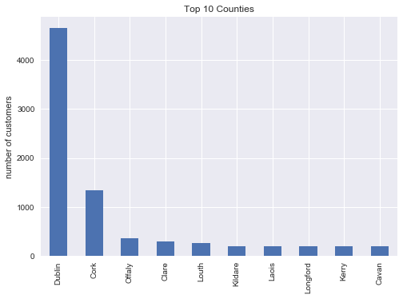

```python
Demographics.County.value_counts()[0:10].plot(kind="bar")
plt.title("Top 10 Counties")
plt.ylabel("number of customers")

plt.show()
```

```python
Demographics[Demographics["County"].isnull()]
```

|  | Client ID | Age | Gender | County | Income Group |
| --- | --- | --- | --- | --- | --- |
| 9799 | 9796 | 53 | 1 | NaN | 60001 - 100000 |
| 9895 | 9892 | 63 | 0 | NaN | 60001 - 100000 |
| 9971 | 9968 | 43 | 0 | NaN | 40001 - 60000 |

Almost half of the customers live in Dublin. They are just 3...Let's assume they belong to Dublin as well.

```python
Demographics = Demographics.fillna(Demographics['County'].value_counts().index[0])
```

Focus now on Income Group

```python
Demographics['Income Group'].unique()
```

```
array([u'10001 - 40000', u'0 - 10000', u'40001 - 60000', u'60001 - 100000',
       u'100000+', u'0  ? 10000', u'10002 - 40000', u'10001 ?. 40000',
       u'10001 ? 40000'], dtype=object)
```

fix the wrong values

```python
Demographics.ix[Demographics['Income Group'] == "10001 ?. 40000", "Income Group"] = "10001 - 40000"
Demographics.ix[Demographics['Income Group'] == "10001 ? 40000", "Income Group"] = "10001 - 40000"
Demographics.ix[Demographics['Income Group'] == "10001 ? 40000", "Income Group"] = "10001 - 40000"
Demographics.ix[Demographics['Income Group'] == "10002 - 40000", "Income Group"] = "10001 - 40000"
Demographics.ix[Demographics['Income Group'] == "0  ? 10000", "Income Group"] = "0 - 10000"
```

```python
Demographics['Income Group'].unique()
```

```
array([u'10001 - 40000', u'0 - 10000', u'40001 - 60000', u'60001 - 100000',
       u'100000+'], dtype=object)
```

In a joint dataset obtained from Demographics and Counties information, I will realize that some of the counties names are misspelled. I correct it now.

```python
Demographics.ix[Demographics['County'].str.contains("Dub"),"County"] = "Dublin"
Demographics.ix[Demographics['County'].str.contains("dub"),"County"] = "Dublin"
Demographics.ix[Demographics['County'].str.contains("blin"),"County"] = "Dublin"
Demographics.ix[Demographics['County'].str.contains("cork"),"County"] = "Cork"
Demographics.ix[Demographics['County'].str.contains("Cork"),"County"] = "Cork"
Demographics.ix[Demographics['County'].str.contains("ongford"),"County"] = "Longford"
```

Ok let's move to the Lookup of the Counties

```python
County = pd.read_excel("County Lkp.xlsx", header=[0])
County.head()
```

|  | SNo | County | Population | Density (/ km2) | Rank | Province | Change since |
| --- | --- | --- | --- | --- | --- | --- | --- |
| 0 | NaN | NaN | NaN | NaN | NaN | NaN | previous census |
| 1 | 1 | Dublin | 1273069.0 | 1380.8 | 1 | Leinster | 0.0702 |
| 2 | 2 | Antrim | 618108.0 | 202.9 | 2 | Ulster | 0.018 |
| 3 | 3 | Down | 531665.0 | 215.6 | 3 | Ulster | 0.0872 |
| 4 | 4 | Cork | 519032.0 | 69.0 | 4 | Munster | 0.0784 |

```python
County.tail(10)
```

|  | SNo | County | Population | Density (/ km2) | Rank | Province | Change since |
| --- | --- | --- | --- | --- | --- | --- | --- |
| 34 | 29 | Monaghan | 60483.0 | 46.7 | 29 | Ulster | 0.0801 |
| 35 | 30 | Carlow | 54612.0 | 60.8 | 30 | Leinster | 0.0847 |
| 36 | 31 | Longford | 39000.0 | 35.7 | 31 | Leinster | 0.134 |
| 37 | 32 | Leitrim | 31796.0 | 19.9 | 32 | Connacht | 0.0984 |
| 38 | NaN | Average | 199974.0 | NaN | NaN | NaN | NaN |
| 39 | NaN | Ireland | 6469688.0 | 76.6 | Total | NaN | NaN |
| 40 | NaN | NaN | NaN | NaN | NaN | NaN | NaN |
| 41 | For other more formats kindly visit www.downlo... | NaN | NaN | NaN | NaN | NaN | NaN |
| 42 | NaN | NaN | NaN | NaN | NaN | NaN | NaN |
| 43 | Original source : en.wikipedia.org/wiki/List_o... | NaN | NaN | NaN | NaN | NaN | NaN |

Even this file is a bit messy.

```python
County = County.rename(columns={'Change since' : "Change"})
County = County[1:-6]
```

for the rank we can use the population, for the SNo it is probably better no to reorder what we have already

```python
County = County.sort_values(["Population"], ascending=False)
County.head()
```

|  | SNo | County | Population | Density (/ km2) | Rank | Province | Change |
| --- | --- | --- | --- | --- | --- | --- | --- |
| 1 | 1 | Dublin | 1273069.0 | 1380.8 | 1 | Leinster | 0.0702 |
| 2 | 2 | Antrim | 618108.0 | 202.9 | 2 | Ulster | 0.018 |
| 3 | 3 | Down | 531665.0 | 215.6 | 3 | Ulster | 0.0872 |
| 4 | 4 | Cork | 519032.0 | 69.0 | 4 | Munster | 0.0784 |
| 5 | - | Fingal | 273991.0 | 600.6 | - | Leinster | 0.1417 |

```python
County.Rank = np.arange(1,len(County)+1)
County.head()
```

|  | SNo | County | Population | Density (/ km2) | Rank | Province | Change |
| --- | --- | --- | --- | --- | --- | --- | --- |
| 1 | 1 | Dublin | 1273069.0 | 1380.8 | 1 | Leinster | 0.0702 |
| 2 | 2 | Antrim | 618108.0 | 202.9 | 2 | Ulster | 0.018 |
| 3 | 3 | Down | 531665.0 | 215.6 | 3 | Ulster | 0.0872 |
| 4 | 4 | Cork | 519032.0 | 69.0 | 4 | Munster | 0.0784 |
| 5 | - | Fingal | 273991.0 | 600.6 | 5 | Leinster | 0.1417 |

```python
County = County.sort_values(["SNo"])
County.tail(6)
```

|  | SNo | County | Population | Density (/ km2) | Rank | Province | Change |
| --- | --- | --- | --- | --- | --- | --- | --- |
| 37 | 32 | Leitrim | 31796.0 | 19.9 | 37 | Connacht | 0.0984 |
| 10 | - | Dun Laoghaire-Rathdown | 206261.0 | 1620.1 | 10 | Leinster | 0.063 |
| 25 | - | South Tipperary | 88432.0 | 39.2 | 25 | Munster | 0.0626 |
| 5 | - | Fingal | 273991.0 | 600.6 | 5 | Leinster | 0.1417 |
| 30 | - | North Tipperary | 70322.0 | 34.4 | 30 | Munster | 0.0661 |
| 6 | - | South Dublin | 265205.0 | 1190.6 | 6 | Leinster | 0.074 |

```python
County.iloc[32:,0] = np.arange(33,38)
```

```python
County.tail(6)
```

|  | SNo | County | Population | Density (/ km2) | Rank | Province | Change |
| --- | --- | --- | --- | --- | --- | --- | --- |
| 37 | 32 | Leitrim | 31796.0 | 19.9 | 37 | Connacht | 0.0984 |
| 10 | 33 | Dun Laoghaire-Rathdown | 206261.0 | 1620.1 | 10 | Leinster | 0.063 |
| 25 | 34 | South Tipperary | 88432.0 | 39.2 | 25 | Munster | 0.0626 |
| 5 | 35 | Fingal | 273991.0 | 600.6 | 5 | Leinster | 0.1417 |
| 30 | 36 | North Tipperary | 70322.0 | 34.4 | 30 | Munster | 0.0661 |
| 6 | 37 | South Dublin | 265205.0 | 1190.6 | 6 | Leinster | 0.074 |

```python
County.describe()
```

|  | SNo | Population | Density (/ km2) | Rank |
| --- | --- | --- | --- | --- |
| count | 37.000000 | 3.700000e+01 | 37.000000 | 37.000000 |
| mean | 19.000000 | 1.973838e+05 | 187.621622 | 19.000000 |
| std | 10.824355 | 2.261722e+05 | 380.938457 | 10.824355 |
| min | 1.000000 | 3.179600e+04 | 19.900000 | 1.000000 |
| 25% | 10.000000 | 7.668700e+04 | 36.100000 | 10.000000 |
| 50% | 19.000000 | 1.366400e+05 | 46.800000 | 19.000000 |
| 75% | 28.000000 | 2.062610e+05 | 119.100000 | 28.000000 |
| max | 37.000000 | 1.273069e+06 | 1620.100000 | 37.000000 |

Change is not meant as a number

```python
County["Change"] = map (lambda x: float(x), County["Change"])
```

Let's go ahead

```python
PreviousLoan = pd.read_csv('Model Build - Previous Loan Holdings.csv', header=0)
PreviousLoan.head()
```

|  | Client ID | Held Loan previously |
| --- | --- | --- |
| 0 | 1 | 1 |
| 1 | 2 | 0 |
| 2 | 3 | 0 |
| 3 | 4 | 1 |
| 4 | 5 | 0 |

```python
PreviousLoan.groupby("Client ID").filter(lambda x: len(x) > 1)
```

|  | Client ID | Held Loan previously |
| --- | --- | --- |
| 20 | 21 | 1 |
| 21 | 21 | 0 |
| 46 | 46 | 0 |
| 47 | 46 | 0 |
| 1221 | 1220 | 0 |
| 1222 | 1220 | 0 |
| 3676 | 3674 | 0 |
| 3677 | 3675 | 0 |
| 3678 | 3674 | 0 |
| 3679 | 3675 | 1 |

As before

```python
PreviousLoan.ix[47, "Client ID"] =  10001
PreviousLoan.ix[1222, "Client ID"] =  10002
PreviousLoan.ix[3678, "Client ID"] =  10003
PreviousLoan.ix[3679, "Client ID"] =  10004
PreviousLoan.drop([21], inplace=True) #we consider the second entry as a correction of the first because this
                                        # specific entry is just here
PreviousLoan.groupby("Client ID").filter(lambda x: len(x) > 1)
```

|  | Client ID | Held Loan previously |
| --- | --- | --- |

```python
PreviousLoan["Held Loan previously"].describe()
```

```
count     10004
unique        4
top           0
freq       7500
Name: Held Loan previously, dtype: object
```

```python
PreviousLoan["Held Loan previously"].unique()
```

```
array(['1', '0', '\xb3', ' \x80-   '], dtype=object)
```

The not recognized values (depends on the pc) are the euro symbol and a kind of 3. Probably they should be related to a yes. All values which are not specified as 0 will be meant as 1.

```python
PreviousLoan["Held Loan previously"] = map ( lambda x: x.decode("ascii", "ignore"), PreviousLoan["Held Loan previously"])
PreviousLoan["Held Loan previously"].unique()
```

```
array([u'1', u'0', u'', u' -   '], dtype=object)
```

```python
def loanExc (x):
    try:
        if int(x) == 0:
            return 0
        else:
            return 1
    except ValueError:
        return 1

PreviousLoan["Held Loan previously"] = map(lambda x: loanExc(x), PreviousLoan["Held Loan previously"])
PreviousLoan["Held Loan previously"].unique()
PreviousLoan["Held Loan previously"].describe()
```

```
count    10004.000000
mean         0.250300
std          0.433207
min          0.000000
25%          0.000000
50%          0.000000
75%          1.000000
max          1.000000
Name: Held Loan previously, dtype: float64
```

ok, we have converted the strange values into 1

```python
BankProducts = pd.read_csv('Model Build - Product Held in Bank.csv', header=None, names=["Client ID","ProductsAmount"])
BankProducts.head()
```

|  | Client ID | ProductsAmount |
| --- | --- | --- |
| 0 | 1 | 4 |
| 1 | 2 | 4 |
| 2 | 3 | 2 |
| 3 | 4 | 2 |
| 4 | 5 | 1 |

```python
BankProducts.describe()
```

|  | Client ID |
| --- | --- |
| count | 10004.000000 |
| mean | 4999.361755 |
| std | 2887.051613 |
| min | 1.000000 |
| 25% | 2499.750000 |
| 50% | 4998.500000 |
| 75% | 7499.250000 |
| max | 10000.000000 |

As before, duplicates IDs.

```python
BankProducts.groupby("Client ID").filter(lambda x: len(x) > 1)
```

|  | Client ID | ProductsAmount |
| --- | --- | --- |
| 45 | 46 | 3 |
| 46 | 46 | 2 |
| 1220 | 1220 | 4 |
| 1221 | 1220 | 4 |
| 3675 | 3674 | 1 |
| 3676 | 3675 | 1 |
| 3677 | 3674 | 2 |
| 3678 | 3675 | 5 |

```python
BankProducts.ix[46, "Client ID"] =  10001
BankProducts.ix[1221, "Client ID"] =  10002
BankProducts.ix[3677, "Client ID"] =  10003
BankProducts.ix[3678, "Client ID"] =  10004
BankProducts.groupby("Client ID").filter(lambda x: len(x) > 1)
```

|  | Client ID | ProductsAmount |
| --- | --- | --- |

```python
BankProducts["ProductsAmount"].unique()
```

```
array(['4', '2', '1', '5', '3', '-1', '-2', ' '], dtype=object)
```

```python
BankProducts.ProductsAmount.value_counts()
```

```
3     2019
2     2012
4     2006
5     1992
1     1969
-1       4
-2       1
         1
Name: ProductsAmount, dtype: int64
```

Since we will probably feed our models with this feature as numerical and not categorical, as it is meant as the number of products used, it would have a sense to replace the " " with the average. The -1 and -2 maybe could be intended as typos, so we delete the minus.

```python
BankProducts.ix[BankProducts["ProductsAmount"]== " ", "ProductsAmount"] = '3'
BankProducts.ix[BankProducts["ProductsAmount"]== "-1", "ProductsAmount"] = '1'
BankProducts.ix[BankProducts["ProductsAmount"]== "-2", "ProductsAmount"] = '2'
BankProducts["ProductsAmount"] = map (lambda x: int(x), BankProducts["ProductsAmount"])
```

```python
BankProducts["ProductsAmount"].unique()
```

```
array([4, 2, 1, 5, 3], dtype=int64)
```

```python
BankProducts.describe()
```

|  | Client ID | ProductsAmount |
| --- | --- | --- |
| count | 10004.00000 | 10004.000000 |
| mean | 5002.50000 | 3.003099 |
| std | 2888.05038 | 1.409714 |
| min | 1.00000 | 1.000000 |
| 25% | 2501.75000 | 2.000000 |
| 50% | 5002.50000 | 3.000000 |
| 75% | 7503.25000 | 4.000000 |
| max | 10004.00000 | 5.000000 |

Move on. For this dataset we have realized that the training and the testing set have been inverted.

```python
TransactionsOut = pd.read_csv('TEST - Transactions out of Current Account.csv', header=0)
TransactionsOut.head()
```

|  | Client | Num Transactions | Last TXN Amount | Merchant Code | Last Transaction Narrative | Unnamed: 5 | Unnamed: 6 | Unnamed: 7 | 0 |
| --- | --- | --- | --- | --- | --- | --- | --- | --- | --- |
| 0 | 1.0 | 0.0 | NaN | NaN | NaN | NaN | NaN | NaN | NaN |
| 1 | 2.0 | 17.0 | 83.66 | 7211.0 | THE BRIDGE LAUNDRY WICKLOW TOWN | NaN | NaN | NaN | NaN |
| 2 | 3.0 | 25.0 | 526.18 | 3667.0 | LUXOR HOTEL/CASINO LAS VEGAS NV | NaN | NaN | NaN | NaN |
| 3 | 4.0 | 13.0 | 70.68 | 5712.0 | HARVEY NORMAN CARRICKMINES | NaN | NaN | NaN | NaN |
| 4 | 5.0 | 39.0 | 259.07 | 5999.0 | PAYPAL *PETEWOODWAR 35314369001 | NaN | NaN | NaN | NaN |

```python
TransactionsOut.columns
```

```
Index([u'Client', u'Num Transactions', u'Last TXN Amount', u'Merchant Code',
       u'Last Transaction Narrative', u'Unnamed: 5', u'Unnamed: 6',
       u'Unnamed: 7', u'0'],
      dtype='object')
```

```python
TransactionsOut = TransactionsOut[TransactionsOut.columns[:5]]
```

```python
TransactionsOut.groupby("Client").filter(lambda x: len(x) > 1)
```

|  | Client | Num Transactions | Last TXN Amount | Merchant Code | Last Transaction Narrative |
| --- | --- | --- | --- | --- | --- |
| 45 | 46.0 | 11.0 | 476.30 | 7829.0 | OMNIPLEX CINEMA LIMERICK LIMERICK CO L |
| 46 | 46.0 | 0.0 | NaN | NaN | NaN |
| 1220 | 1220.0 | 14.0 | 316.90 | 3008.0 | LUFTHANSA AG2201000000000FRANKFURT |
| 1221 | 1220.0 | 14.0 | 492.88 | 7311.0 | THE IRISH TIMES LTD DUBLIN |
| 3675 | 3674.0 | 19.0 | 838.98 | 5211.0 | B & Q IRELAND TALLAGHT |
| 3676 | 3674.0 | 0.0 | NaN | NaN | NaN |
| 3677 | 3675.0 | 11.0 | 789.95 | 3364.0 | TICKET DESK CHARLEROI GOSSELIES |
| 3678 | 3675.0 | 17.0 | 509.55 | 8049.0 | FOOT STOP LIMITED NAAS |

```python
TransactionsOut.ix[46, "Client"] =  10001
TransactionsOut.ix[1221, "Client"] =  10002
TransactionsOut.ix[3676, "Client"] =  10003
TransactionsOut.ix[3678, "Client"] =  10004
TransactionsOut.groupby("Client").filter(lambda x: len(x) > 1)
```

|  | Client | Num Transactions | Last TXN Amount | Merchant Code | Last Transaction Narrative |
| --- | --- | --- | --- | --- | --- |

```python
TransactionsOut.describe()
```

|  | Client | Num Transactions | Last TXN Amount | Merchant Code |
| --- | --- | --- | --- | --- |
| count | 10004.00000 | 10004.000000 | 6724.000000 | 6724.000000 |
| mean | 5002.50000 | 18.288685 | 451.721841 | 4817.466984 |
| std | 2888.05038 | 22.959727 | 258.305702 | 1820.237256 |
| min | 1.00000 | 0.000000 | 5.390000 | 742.000000 |
| 25% | 2501.75000 | 0.000000 | 225.437500 | 3508.000000 |
| 50% | 5002.50000 | 10.000000 | 450.285000 | 3793.000000 |
| 75% | 7503.25000 | 29.250000 | 674.852500 | 5950.000000 |
| max | 10004.00000 | 100.000000 | 899.860000 | 9950.000000 |

```python
TransactionsOut.head()
```

|  | Client | Num Transactions | Last TXN Amount | Merchant Code | Last Transaction Narrative |
| --- | --- | --- | --- | --- | --- |
| 0 | 1.0 | 0.0 | NaN | NaN | NaN |
| 1 | 2.0 | 17.0 | 83.66 | 7211.0 | THE BRIDGE LAUNDRY WICKLOW TOWN |
| 2 | 3.0 | 25.0 | 526.18 | 3667.0 | LUXOR HOTEL/CASINO LAS VEGAS NV |
| 3 | 4.0 | 13.0 | 70.68 | 5712.0 | HARVEY NORMAN CARRICKMINES |
| 4 | 5.0 | 39.0 | 259.07 | 5999.0 | PAYPAL *PETEWOODWAR 35314369001 |

The NaNs have a sense here. Let's keep them for now.

```python
TxnAmount = pd.read_csv('Model Build - TXN Amount.csv', header=None, encoding='ISO-8859-15', names = ["Client", "TxnAmount"])
TxnAmount.head()
```

|  | Client | TxnAmount |
| --- | --- | --- |
| 0 | 1 | 58 |
| 1 | 2 | 2,663 |
| 2 | 3 | 46 |
| 3 | 4 | 0 |
| 4 | 5 | 126 |

```python
TxnAmount.groupby("Client").filter(lambda x: len(x) > 1)
```

|  | Client | TxnAmount |
| --- | --- | --- |
| 45 | 46 | 0 |
| 46 | 46 | 0 |
| 1220 | 1220 | 57 |
| 1221 | 1220 | 57 |
| 3675 | 3674 | 0 |
| 3676 | 3675 | 0 |
| 3677 | 3674 | 0 |
| 3678 | 3675 | 1,636 |

```python
TxnAmount.ix[46, "Client"] =  10001
TxnAmount.ix[1221, "Client"] =  10002
TxnAmount.ix[3677, "Client"] =  10003
TxnAmount.ix[3678, "Client"] =  10004
TxnAmount.groupby("Client").filter(lambda x: len(x) > 1)
```

|  | Client | TxnAmount |
| --- | --- | --- |

The euro symbol could give some problems with some configurations. Also the comma used to count the thousands.

```python
TxnAmount["TxnAmount"] = map ( lambda x: x.encode("ascii", "ignore"), TxnAmount["TxnAmount"]) #depends on the pc
TxnAmount["TxnAmount"] = map (lambda x: x.replace(",",""), TxnAmount["TxnAmount"])
TxnAmount["TxnAmount"] = map (lambda x: float(x), TxnAmount["TxnAmount"])
TxnAmount.head()
```

|  | Client | TxnAmount |
| --- | --- | --- |
| 0 | 1 | 58.0 |
| 1 | 2 | 2663.0 |
| 2 | 3 | 46.0 |
| 3 | 4 | 0.0 |
| 4 | 5 | 126.0 |

```python
Target = pd.read_csv('Target Variable - Purchased Loan Flag.csv', header=0)
Target.head()
```

|  | Client ID | Loan Flag | Unnamed: 2 | Unnamed: 3 |
| --- | --- | --- | --- | --- |
| 0 | 1 | 0 | NaN | NaN |
| 1 | 2 | 0 | NaN | NaN |
| 2 | 3 | 0 | NaN | NaN |
| 3 | 4 | 0 | NaN | NaN |
| 4 | 5 | 0 | NaN | NaN |

```python
Target = Target[Target.columns[:2]]
Target.describe()
```

|  | Client ID | Loan Flag |
| --- | --- | --- |
| count | 10004.000000 | 10004.000000 |
| mean | 4999.361755 | 0.021092 |
| std | 2887.051613 | 0.143697 |
| min | 1.000000 | 0.000000 |
| 25% | 2499.750000 | 0.000000 |
| 50% | 4998.500000 | 0.000000 |
| 75% | 7499.250000 | 0.000000 |
| max | 10000.000000 | 1.000000 |

```python
Target.groupby("Client ID").filter(lambda x: len(x) > 1)
```

|  | Client ID | Loan Flag |
| --- | --- | --- |
| 45 | 46 | 0 |
| 46 | 46 | 0 |
| 1220 | 1220 | 0 |
| 1221 | 1220 | 0 |
| 3675 | 3674 | 0 |
| 3676 | 3675 | 0 |
| 3677 | 3674 | 0 |
| 3678 | 3675 | 0 |

```python
Target.ix[46, "Client ID"] =  10001
Target.ix[1221, "Client ID"] =  10002
Target.ix[3677, "Client ID"] =  10003
Target.ix[3678, "Client ID"] =  10004
Target.groupby("Client ID").filter(lambda x: len(x) > 1)
```

|  | Client ID | Loan Flag |
| --- | --- | --- |

Ok. let's try to join these datasets to fullfil the BI assignments. I know that JoinTest is not the best name for this :)

```python
JoinTest = pd.merge(Demographics,County, how = 'outer', left_on='County', right_on='County')
JoinTest = pd.merge(JoinTest,PreviousLoan, how = 'outer', left_on='Client ID', right_on='Client ID')
JoinTest = pd.merge(JoinTest,BankProducts, how = 'outer', left_on='Client ID', right_on='Client ID')
JoinTest = pd.merge(JoinTest,TransactionsOut, how = 'outer', left_on='Client ID', right_on='Client')
JoinTest = pd.merge(JoinTest,TxnAmount, how = 'outer', left_on='Client ID', right_on='Client')
JoinTest = pd.merge(JoinTest,Target, how = 'outer', left_on='Client ID', right_on='Client ID')
JoinTest.head()
```

|  | Client ID | Age | Gender | County | Income Group | SNo | Population | Density (/ km2) | Rank | Province | ... | Held Loan previously | ProductsAmount | Client_x | Num Transactions | Last TXN Amount | Merchant Code | Last Transaction Narrative | Client_y | TxnAmount | Loan Flag |
| --- | --- | --- | --- | --- | --- | --- | --- | --- | --- | --- | --- | --- | --- | --- | --- | --- | --- | --- | --- | --- | --- |
| 0 | 1.0 | 36.0 | 1.0 | Cork | 10001 - 40000 | 4.0 | 519032.0 | 69.0 | 4.0 | Munster | ... | 1.0 | 4.0 | 1.0 | 0.0 | NaN | NaN | NaN | 1.0 | 58.0 | 0.0 |
| 1 | 9.0 | 24.0 | 0.0 | Cork | 60001 - 100000 | 4.0 | 519032.0 | 69.0 | 4.0 | Munster | ... | 0.0 | 4.0 | 9.0 | 5.0 | 45.00 | 5972.0 | DUBLIN MINT OFFICE LONDON | 9.0 | 22.0 | 0.0 |
| 2 | 24.0 | 57.0 | 1.0 | Cork | 10001 - 40000 | 4.0 | 519032.0 | 69.0 | 4.0 | Munster | ... | 0.0 | 2.0 | 24.0 | 11.0 | 890.00 | 5192.0 | EASONS KILKENNY CO DUBLIN | 24.0 | 0.0 | 0.0 |
| 3 | 37.0 | 21.0 | 1.0 | Cork | 10001 - 40000 | 4.0 | 519032.0 | 69.0 | 4.0 | Munster | ... | 1.0 | 1.0 | 37.0 | 4.0 | 247.65 | 4468.0 | MARINE SUPPLIERS DUBLIN | 37.0 | 28.0 | 0.0 |
| 4 | 38.0 | 60.0 | 0.0 | Cork | 100000+ | 4.0 | 519032.0 | 69.0 | 4.0 | Munster | ... | 0.0 | 4.0 | 38.0 | 9.0 | 220.27 | 3420.0 | ENTERPRISE GUERIN RENT FARO | 38.0 | 0.0 | 0.0 |

5 rows × 21 columns

```python
JoinTest['Client ID'].describe()
```

```
count    10004.00000
mean      5002.50000
std       2888.05038
min          1.00000
25%       2501.75000
50%       5002.50000
75%       7503.25000
max      10004.00000
Name: Client ID, dtype: float64
```

```python
JoinTest[pd.isnull(JoinTest['SNo'])]
```

|  | Client ID | Age | Gender | County | Income Group | SNo | Population | Density (/ km2) | Rank | Province | ... | Held Loan previously | ProductsAmount | Client_x | Num Transactions | Last TXN Amount | Merchant Code | Last Transaction Narrative | Client_y | TxnAmount | Loan Flag |
| --- | --- | --- | --- | --- | --- | --- | --- | --- | --- | --- | --- | --- | --- | --- | --- | --- | --- | --- | --- | --- | --- |
| 9980 | 267.0 | 65.0 | 1.0 | Navan | 10001 - 40000 | NaN | NaN | NaN | NaN | NaN | ... | 0.0 | 2.0 | 267.0 | 0.0 | NaN | NaN | NaN | 267.0 | 864.0 | 0.0 |
| 9981 | 323.0 | 37.0 | 1.0 | Borris | 10001 - 40000 | NaN | NaN | NaN | NaN | NaN | ... | 0.0 | 2.0 | 323.0 | 17.0 | 740.69 | 9950.0 | Hurst Heating & Plumbin Caslebar, co | 323.0 | 1418.0 | 0.0 |
| 9982 | 381.0 | 66.0 | 1.0 | Sandyford | 10001 - 40000 | NaN | NaN | NaN | NaN | NaN | ... | 0.0 | 5.0 | 381.0 | 1.0 | 790.51 | 5331.0 | PAYPAL *NETMEDIALLC 35314369001 | 381.0 | 0.0 | 0.0 |
| 9983 | 524.0 | 43.0 | 0.0 | Maynooth | 10001 - 40000 | NaN | NaN | NaN | NaN | NaN | ... | 1.0 | 5.0 | 524.0 | 95.0 | 616.98 | 5733.0 | SOUNDTRAX CAMDEN QUAY | 524.0 | 93.0 | 1.0 |
| 9984 | 569.0 | 49.0 | 1.0 | Portlaoise | 40001 - 60000 | NaN | NaN | NaN | NaN | NaN | ... | 0.0 | 3.0 | 569.0 | 0.0 | NaN | NaN | NaN | 569.0 | 377.0 | 0.0 |
| 9985 | 654.0 | 37.0 | 1.0 | Trim | 100000+ | NaN | NaN | NaN | NaN | NaN | ... | 0.0 | 5.0 | 654.0 | 0.0 | NaN | NaN | NaN | 654.0 | 331.0 | 0.0 |
| 9986 | 721.0 | 59.0 | 1.0 | Ballina | 60001 - 100000 | NaN | NaN | NaN | NaN | NaN | ... | 0.0 | 3.0 | 721.0 | 3.0 | 79.76 | 5964.0 | LITTLEWOODS IRELAND BLANCHARDSTOW | 721.0 | 0.0 | 0.0 |
| 9987 | 867.0 | 24.0 | 0.0 | Spain | 10001 - 40000 | NaN | NaN | NaN | NaN | NaN | ... | 0.0 | 2.0 | 867.0 | 6.0 | 132.62 | 4468.0 | RAYMARINE UK LTD PORTSMOUTH | 867.0 | 209.0 | 0.0 |
| 9988 | 1080.0 | 64.0 | 0.0 | Sligo Town | 10001 - 40000 | NaN | NaN | NaN | NaN | NaN | ... | 0.0 | 3.0 | 1080.0 | 2.0 | 862.78 | 3659.0 | TAJ LONDON LONDON | 1080.0 | 419.0 | 0.0 |
| 9989 | 1289.0 | 34.0 | 1.0 | Rosslare | 100000+ | NaN | NaN | NaN | NaN | NaN | ... | 0.0 | 1.0 | 1289.0 | 40.0 | 327.11 | 8675.0 | AA IRELAND DUBLIN | 1289.0 | 0.0 | 0.0 |
| 9990 | 1331.0 | 28.0 | 1.0 | Northern Ireland | 10001 - 40000 | NaN | NaN | NaN | NaN | NaN | ... | 0.0 | 1.0 | 1331.0 | 26.0 | 621.03 | 5718.0 | WESTMEATH STONE CO.WESTMEATH | 1331.0 | 2185.0 | 0.0 |
| 9991 | 1407.0 | 60.0 | 0.0 | Lahinch | 60001 - 100000 | NaN | NaN | NaN | NaN | NaN | ... | 0.0 | 4.0 | 1407.0 | 40.0 | 317.29 | 3068.0 | AIR ASTANA ALMATY | 1407.0 | 1752.0 | 0.0 |
| 9992 | 1626.0 | 23.0 | 1.0 | Adare | 60001 - 100000 | NaN | NaN | NaN | NaN | NaN | ... | 0.0 | 2.0 | 1626.0 | 7.0 | 170.27 | 4784.0 | EFLOW BARRIER FREE TOL DUBLIN 4 | 1626.0 | 0.0 | 0.0 |
| 9993 | 7461.0 | 33.0 | 0.0 | Boyle | 10001 - 40000 | NaN | NaN | NaN | NaN | NaN | ... | 1.0 | 4.0 | 7461.0 | 1.0 | 553.73 | 7216.0 | QUALITY DRY CLEANERS DUBLIN 16 | 7461.0 | 2064.0 | 0.0 |
| 9994 | 7618.0 | 24.0 | 1.0 | Co. Kerry | 10001 - 40000 | NaN | NaN | NaN | NaN | NaN | ... | 0.0 | 4.0 | 7618.0 | 0.0 | NaN | NaN | NaN | 7618.0 | 36.0 | 0.0 |
| 9995 | 7935.0 | 65.0 | 1.0 | 999 | 10001 - 40000 | NaN | NaN | NaN | NaN | NaN | ... | 1.0 | 4.0 | 7935.0 | 56.0 | 399.95 | 8062.0 | TUNG SHIN HOSPITAL KUALA LUMPUR | 7935.0 | 402.0 | 0.0 |
| 9996 | 8099.0 | 28.0 | 0.0 | 999 | 60001 - 100000 | NaN | NaN | NaN | NaN | NaN | ... | 0.0 | 2.0 | 8099.0 | 53.0 | 430.75 | 7933.0 | THE DIAMOND BOWL & KIDZONWICKLOW TOWN | 8099.0 | 1099.0 | 0.0 |
| 9997 | 8201.0 | 55.0 | 1.0 |  | 60001 - 100000 | NaN | NaN | NaN | NaN | NaN | ... | 0.0 | 3.0 | 8201.0 | 0.0 | NaN | NaN | NaN | 8201.0 | 440.0 | 0.0 |
| 9998 | 8297.0 | 27.0 | 1.0 | County Mayo | 40001 - 60000 | NaN | NaN | NaN | NaN | NaN | ... | 0.0 | 5.0 | 8297.0 | 0.0 | NaN | NaN | NaN | 8297.0 | 0.0 | 0.0 |
| 9999 | 8631.0 | 38.0 | 0.0 | kildare Town | 60001 - 100000 | NaN | NaN | NaN | NaN | NaN | ... | 0.0 | 1.0 | 8631.0 | 0.0 | NaN | NaN | NaN | 8631.0 | 361.0 | 0.0 |
| 10000 | 8653.0 | 36.0 | 0.0 | clare | 10001 - 40000 | NaN | NaN | NaN | NaN | NaN | ... | 0.0 | 3.0 | 8653.0 | 26.0 | 370.74 | 3548.0 | SOL HOUSE ALOHA TORREMOLINOS | 8653.0 | 0.0 | 0.0 |
| 10001 | 8746.0 | 33.0 | 0.0 | leitrim | 10001 - 40000 | NaN | NaN | NaN | NaN | NaN | ... | 0.0 | 1.0 | 8746.0 | 0.0 | NaN | NaN | NaN | 8746.0 | 0.0 | 0.0 |
| 10002 | 8815.0 | 65.0 | 0.0 | offaly | 10001 - 40000 | NaN | NaN | NaN | NaN | NaN | ... | 0.0 | 2.0 | 8815.0 | 0.0 | NaN | NaN | NaN | 8815.0 | 1661.0 | 0.0 |
| 10003 | 8841.0 | 43.0 | 0.0 | Kildare town | 60001 - 100000 | NaN | NaN | NaN | NaN | NaN | ... | 0.0 | 3.0 | 8841.0 | 14.0 | 886.64 | 5551.0 | MOONEY BOATS KILLYBEGS | 8841.0 | 0.0 | 0.0 |

24 rows × 21 columns

These are the guys with the wrong county names. They are just 24. The BI assignments should not involve them.

```python
JoinTest[pd.isnull(JoinTest['Client ID'])]
```

|  | Client ID | Age | Gender | County | Income Group | SNo | Population | Density (/ km2) | Rank | Province | ... | Held Loan previously | ProductsAmount | Client_x | Num Transactions | Last TXN Amount | Merchant Code | Last Transaction Narrative | Client_y | TxnAmount | Loan Flag |
| --- | --- | --- | --- | --- | --- | --- | --- | --- | --- | --- | --- | --- | --- | --- | --- | --- | --- | --- | --- | --- | --- |
| 10004 | NaN | NaN | NaN | Antrim | NaN | 2.0 | 618108.0 | 202.9 | 2.0 | Ulster | ... | NaN | NaN | NaN | NaN | NaN | NaN | NaN | NaN | NaN | NaN |
| 10005 | NaN | NaN | NaN | Antrim | NaN | 2.0 | 618108.0 | 202.9 | 2.0 | Ulster | ... | NaN | NaN | NaN | NaN | NaN | NaN | NaN | NaN | NaN | NaN |
| 10006 | NaN | NaN | NaN | Antrim | NaN | 2.0 | 618108.0 | 202.9 | 2.0 | Ulster | ... | NaN | NaN | NaN | NaN | NaN | NaN | NaN | NaN | NaN | NaN |
| 10007 | NaN | NaN | NaN | Antrim | NaN | 2.0 | 618108.0 | 202.9 | 2.0 | Ulster | ... | NaN | NaN | NaN | NaN | NaN | NaN | NaN | NaN | NaN | NaN |
| 10008 | NaN | NaN | NaN | Antrim | NaN | 2.0 | 618108.0 | 202.9 | 2.0 | Ulster | ... | NaN | NaN | NaN | NaN | NaN | NaN | NaN | NaN | NaN | NaN |
| 10009 | NaN | NaN | NaN | Antrim | NaN | 2.0 | 618108.0 | 202.9 | 2.0 | Ulster | ... | NaN | NaN | NaN | NaN | NaN | NaN | NaN | NaN | NaN | NaN |
| 10010 | NaN | NaN | NaN | Antrim | NaN | 2.0 | 618108.0 | 202.9 | 2.0 | Ulster | ... | NaN | NaN | NaN | NaN | NaN | NaN | NaN | NaN | NaN | NaN |
| 10011 | NaN | NaN | NaN | Antrim | NaN | 2.0 | 618108.0 | 202.9 | 2.0 | Ulster | ... | NaN | NaN | NaN | NaN | NaN | NaN | NaN | NaN | NaN | NaN |
| 10012 | NaN | NaN | NaN | Antrim | NaN | 2.0 | 618108.0 | 202.9 | 2.0 | Ulster | ... | NaN | NaN | NaN | NaN | NaN | NaN | NaN | NaN | NaN | NaN |
| 10013 | NaN | NaN | NaN | Antrim | NaN | 2.0 | 618108.0 | 202.9 | 2.0 | Ulster | ... | NaN | NaN | NaN | NaN | NaN | NaN | NaN | NaN | NaN | NaN |
| 10014 | NaN | NaN | NaN | Antrim | NaN | 2.0 | 618108.0 | 202.9 | 2.0 | Ulster | ... | NaN | NaN | NaN | NaN | NaN | NaN | NaN | NaN | NaN | NaN |
| 10015 | NaN | NaN | NaN | Antrim | NaN | 2.0 | 618108.0 | 202.9 | 2.0 | Ulster | ... | NaN | NaN | NaN | NaN | NaN | NaN | NaN | NaN | NaN | NaN |
| 10016 | NaN | NaN | NaN | Antrim | NaN | 2.0 | 618108.0 | 202.9 | 2.0 | Ulster | ... | NaN | NaN | NaN | NaN | NaN | NaN | NaN | NaN | NaN | NaN |
| 10017 | NaN | NaN | NaN | Antrim | NaN | 2.0 | 618108.0 | 202.9 | 2.0 | Ulster | ... | NaN | NaN | NaN | NaN | NaN | NaN | NaN | NaN | NaN | NaN |
| 10018 | NaN | NaN | NaN | Antrim | NaN | 2.0 | 618108.0 | 202.9 | 2.0 | Ulster | ... | NaN | NaN | NaN | NaN | NaN | NaN | NaN | NaN | NaN | NaN |
| 10019 | NaN | NaN | NaN | Antrim | NaN | 2.0 | 618108.0 | 202.9 | 2.0 | Ulster | ... | NaN | NaN | NaN | NaN | NaN | NaN | NaN | NaN | NaN | NaN |
| 10020 | NaN | NaN | NaN | Antrim | NaN | 2.0 | 618108.0 | 202.9 | 2.0 | Ulster | ... | NaN | NaN | NaN | NaN | NaN | NaN | NaN | NaN | NaN | NaN |
| 10021 | NaN | NaN | NaN | Antrim | NaN | 2.0 | 618108.0 | 202.9 | 2.0 | Ulster | ... | NaN | NaN | NaN | NaN | NaN | NaN | NaN | NaN | NaN | NaN |
| 10022 | NaN | NaN | NaN | Antrim | NaN | 2.0 | 618108.0 | 202.9 | 2.0 | Ulster | ... | NaN | NaN | NaN | NaN | NaN | NaN | NaN | NaN | NaN | NaN |
| 10023 | NaN | NaN | NaN | Antrim | NaN | 2.0 | 618108.0 | 202.9 | 2.0 | Ulster | ... | NaN | NaN | NaN | NaN | NaN | NaN | NaN | NaN | NaN | NaN |
| 10024 | NaN | NaN | NaN | Antrim | NaN | 2.0 | 618108.0 | 202.9 | 2.0 | Ulster | ... | NaN | NaN | NaN | NaN | NaN | NaN | NaN | NaN | NaN | NaN |
| 10025 | NaN | NaN | NaN | Antrim | NaN | 2.0 | 618108.0 | 202.9 | 2.0 | Ulster | ... | NaN | NaN | NaN | NaN | NaN | NaN | NaN | NaN | NaN | NaN |
| 10026 | NaN | NaN | NaN | Antrim | NaN | 2.0 | 618108.0 | 202.9 | 2.0 | Ulster | ... | NaN | NaN | NaN | NaN | NaN | NaN | NaN | NaN | NaN | NaN |
| 10027 | NaN | NaN | NaN | Antrim | NaN | 2.0 | 618108.0 | 202.9 | 2.0 | Ulster | ... | NaN | NaN | NaN | NaN | NaN | NaN | NaN | NaN | NaN | NaN |
| 10028 | NaN | NaN | NaN | Antrim | NaN | 2.0 | 618108.0 | 202.9 | 2.0 | Ulster | ... | NaN | NaN | NaN | NaN | NaN | NaN | NaN | NaN | NaN | NaN |
| 10029 | NaN | NaN | NaN | Antrim | NaN | 2.0 | 618108.0 | 202.9 | 2.0 | Ulster | ... | NaN | NaN | NaN | NaN | NaN | NaN | NaN | NaN | NaN | NaN |
| 10030 | NaN | NaN | NaN | Antrim | NaN | 2.0 | 618108.0 | 202.9 | 2.0 | Ulster | ... | NaN | NaN | NaN | NaN | NaN | NaN | NaN | NaN | NaN | NaN |
| 10031 | NaN | NaN | NaN | Antrim | NaN | 2.0 | 618108.0 | 202.9 | 2.0 | Ulster | ... | NaN | NaN | NaN | NaN | NaN | NaN | NaN | NaN | NaN | NaN |
| 10032 | NaN | NaN | NaN | Antrim | NaN | 2.0 | 618108.0 | 202.9 | 2.0 | Ulster | ... | NaN | NaN | NaN | NaN | NaN | NaN | NaN | NaN | NaN | NaN |
| 10033 | NaN | NaN | NaN | Antrim | NaN | 2.0 | 618108.0 | 202.9 | 2.0 | Ulster | ... | NaN | NaN | NaN | NaN | NaN | NaN | NaN | NaN | NaN | NaN |
| ... | ... | ... | ... | ... | ... | ... | ... | ... | ... | ... | ... | ... | ... | ... | ... | ... | ... | ... | ... | ... | ... |
| 28229 | NaN | NaN | NaN | South Dublin | NaN | 37.0 | 265205.0 | 1190.6 | 6.0 | Leinster | ... | NaN | NaN | NaN | NaN | NaN | NaN | NaN | NaN | NaN | NaN |
| 28230 | NaN | NaN | NaN | South Dublin | NaN | 37.0 | 265205.0 | 1190.6 | 6.0 | Leinster | ... | NaN | NaN | NaN | NaN | NaN | NaN | NaN | NaN | NaN | NaN |
| 28231 | NaN | NaN | NaN | South Dublin | NaN | 37.0 | 265205.0 | 1190.6 | 6.0 | Leinster | ... | NaN | NaN | NaN | NaN | NaN | NaN | NaN | NaN | NaN | NaN |
| 28232 | NaN | NaN | NaN | South Dublin | NaN | 37.0 | 265205.0 | 1190.6 | 6.0 | Leinster | ... | NaN | NaN | NaN | NaN | NaN | NaN | NaN | NaN | NaN | NaN |
| 28233 | NaN | NaN | NaN | South Dublin | NaN | 37.0 | 265205.0 | 1190.6 | 6.0 | Leinster | ... | NaN | NaN | NaN | NaN | NaN | NaN | NaN | NaN | NaN | NaN |
| 28234 | NaN | NaN | NaN | South Dublin | NaN | 37.0 | 265205.0 | 1190.6 | 6.0 | Leinster | ... | NaN | NaN | NaN | NaN | NaN | NaN | NaN | NaN | NaN | NaN |
| 28235 | NaN | NaN | NaN | South Dublin | NaN | 37.0 | 265205.0 | 1190.6 | 6.0 | Leinster | ... | NaN | NaN | NaN | NaN | NaN | NaN | NaN | NaN | NaN | NaN |
| 28236 | NaN | NaN | NaN | South Dublin | NaN | 37.0 | 265205.0 | 1190.6 | 6.0 | Leinster | ... | NaN | NaN | NaN | NaN | NaN | NaN | NaN | NaN | NaN | NaN |
| 28237 | NaN | NaN | NaN | South Dublin | NaN | 37.0 | 265205.0 | 1190.6 | 6.0 | Leinster | ... | NaN | NaN | NaN | NaN | NaN | NaN | NaN | NaN | NaN | NaN |
| 28238 | NaN | NaN | NaN | South Dublin | NaN | 37.0 | 265205.0 | 1190.6 | 6.0 | Leinster | ... | NaN | NaN | NaN | NaN | NaN | NaN | NaN | NaN | NaN | NaN |
| 28239 | NaN | NaN | NaN | South Dublin | NaN | 37.0 | 265205.0 | 1190.6 | 6.0 | Leinster | ... | NaN | NaN | NaN | NaN | NaN | NaN | NaN | NaN | NaN | NaN |
| 28240 | NaN | NaN | NaN | South Dublin | NaN | 37.0 | 265205.0 | 1190.6 | 6.0 | Leinster | ... | NaN | NaN | NaN | NaN | NaN | NaN | NaN | NaN | NaN | NaN |
| 28241 | NaN | NaN | NaN | South Dublin | NaN | 37.0 | 265205.0 | 1190.6 | 6.0 | Leinster | ... | NaN | NaN | NaN | NaN | NaN | NaN | NaN | NaN | NaN | NaN |
| 28242 | NaN | NaN | NaN | South Dublin | NaN | 37.0 | 265205.0 | 1190.6 | 6.0 | Leinster | ... | NaN | NaN | NaN | NaN | NaN | NaN | NaN | NaN | NaN | NaN |
| 28243 | NaN | NaN | NaN | South Dublin | NaN | 37.0 | 265205.0 | 1190.6 | 6.0 | Leinster | ... | NaN | NaN | NaN | NaN | NaN | NaN | NaN | NaN | NaN | NaN |
| 28244 | NaN | NaN | NaN | South Dublin | NaN | 37.0 | 265205.0 | 1190.6 | 6.0 | Leinster | ... | NaN | NaN | NaN | NaN | NaN | NaN | NaN | NaN | NaN | NaN |
| 28245 | NaN | NaN | NaN | South Dublin | NaN | 37.0 | 265205.0 | 1190.6 | 6.0 | Leinster | ... | NaN | NaN | NaN | NaN | NaN | NaN | NaN | NaN | NaN | NaN |
| 28246 | NaN | NaN | NaN | South Dublin | NaN | 37.0 | 265205.0 | 1190.6 | 6.0 | Leinster | ... | NaN | NaN | NaN | NaN | NaN | NaN | NaN | NaN | NaN | NaN |
| 28247 | NaN | NaN | NaN | South Dublin | NaN | 37.0 | 265205.0 | 1190.6 | 6.0 | Leinster | ... | NaN | NaN | NaN | NaN | NaN | NaN | NaN | NaN | NaN | NaN |
| 28248 | NaN | NaN | NaN | South Dublin | NaN | 37.0 | 265205.0 | 1190.6 | 6.0 | Leinster | ... | NaN | NaN | NaN | NaN | NaN | NaN | NaN | NaN | NaN | NaN |
| 28249 | NaN | NaN | NaN | South Dublin | NaN | 37.0 | 265205.0 | 1190.6 | 6.0 | Leinster | ... | NaN | NaN | NaN | NaN | NaN | NaN | NaN | NaN | NaN | NaN |
| 28250 | NaN | NaN | NaN | South Dublin | NaN | 37.0 | 265205.0 | 1190.6 | 6.0 | Leinster | ... | NaN | NaN | NaN | NaN | NaN | NaN | NaN | NaN | NaN | NaN |
| 28251 | NaN | NaN | NaN | South Dublin | NaN | 37.0 | 265205.0 | 1190.6 | 6.0 | Leinster | ... | NaN | NaN | NaN | NaN | NaN | NaN | NaN | NaN | NaN | NaN |
| 28252 | NaN | NaN | NaN | South Dublin | NaN | 37.0 | 265205.0 | 1190.6 | 6.0 | Leinster | ... | NaN | NaN | NaN | NaN | NaN | NaN | NaN | NaN | NaN | NaN |
| 28253 | NaN | NaN | NaN | South Dublin | NaN | 37.0 | 265205.0 | 1190.6 | 6.0 | Leinster | ... | NaN | NaN | NaN | NaN | NaN | NaN | NaN | NaN | NaN | NaN |
| 28254 | NaN | NaN | NaN | South Dublin | NaN | 37.0 | 265205.0 | 1190.6 | 6.0 | Leinster | ... | NaN | NaN | NaN | NaN | NaN | NaN | NaN | NaN | NaN | NaN |
| 28255 | NaN | NaN | NaN | South Dublin | NaN | 37.0 | 265205.0 | 1190.6 | 6.0 | Leinster | ... | NaN | NaN | NaN | NaN | NaN | NaN | NaN | NaN | NaN | NaN |
| 28256 | NaN | NaN | NaN | South Dublin | NaN | 37.0 | 265205.0 | 1190.6 | 6.0 | Leinster | ... | NaN | NaN | NaN | NaN | NaN | NaN | NaN | NaN | NaN | NaN |
| 28257 | NaN | NaN | NaN | South Dublin | NaN | 37.0 | 265205.0 | 1190.6 | 6.0 | Leinster | ... | NaN | NaN | NaN | NaN | NaN | NaN | NaN | NaN | NaN | NaN |
| 28258 | NaN | NaN | NaN | South Dublin | NaN | 37.0 | 265205.0 | 1190.6 | 6.0 | Leinster | ... | NaN | NaN | NaN | NaN | NaN | NaN | NaN | NaN | NaN | NaN |

18255 rows × 21 columns

Counties without any customers (due to the outer join). Remove them

```python
JoinTest = JoinTest[np.logical_not(pd.isnull(JoinTest['Age']))]
```

Business Intelligence:

1. How Many Customers above 50 years old have taken on a loan?

```python
over50Loan = JoinTest[(JoinTest["Age"] >= 50) & (JoinTest["Loan Flag"] == 1)]
under50Loan = JoinTest[(JoinTest["Age"] < 50)& (JoinTest["Loan Flag"] == 1)]
over50Loan.head()
```

|  | Client ID | Age | Gender | County | Income Group | SNo | Population | Density (/ km2) | Rank | Province | ... | Held Loan previously | ProductsAmount | Client_x | Num Transactions | Last TXN Amount | Merchant Code | Last Transaction Narrative | Client_y | TxnAmount | Loan Flag |
| --- | --- | --- | --- | --- | --- | --- | --- | --- | --- | --- | --- | --- | --- | --- | --- | --- | --- | --- | --- | --- | --- |
| 131 | 1026.0 | 67.0 | 0.0 | Cork | 10001 - 40000 | 4.0 | 519032.0 | 69.0 | 4.0 | Munster | ... | 0.0 | 4.0 | 1026.0 | 31.0 | 257.81 | 3502.0 | BEST WESTERN YOSEMITE WY MARIPOSA CA | 1026.0 | 8125.0 | 1.0 |
| 754 | 5586.0 | 54.0 | 0.0 | Cork | 10001 - 40000 | 4.0 | 519032.0 | 69.0 | 4.0 | Munster | ... | 1.0 | 1.0 | 5586.0 | 32.0 | 253.93 | 7339.0 | REGISTER MY COMPANY DUBLIN 2 | 5586.0 | 2647.0 | 1.0 |
| 904 | 6733.0 | 69.0 | 0.0 | Cork | 10001 - 40000 | 4.0 | 519032.0 | 69.0 | 4.0 | Munster | ... | 1.0 | 3.0 | 6733.0 | 100.0 | 168.33 | 4723.0 | FLYCOUK 0572582989880BERLIN | 6733.0 | 0.0 | 1.0 |
| 1060 | 7982.0 | 55.0 | 1.0 | Cork | 10001 - 40000 | 4.0 | 519032.0 | 69.0 | 4.0 | Munster | ... | 0.0 | 4.0 | 7982.0 | 13.0 | 633.97 | 3014.0 | SAUDI ARABIAN AIRLINES JEDDAH | 7982.0 | 0.0 | 1.0 |
| 1109 | 8302.0 | 70.0 | 0.0 | Cork | 10001 - 40000 | 4.0 | 519032.0 | 69.0 | 4.0 | Munster | ... | 1.0 | 4.0 | 8302.0 | 19.0 | 141.15 | 5973.0 | ANGEL INSPIRATIONS SANDYMOUNT | 8302.0 | 6006.0 | 1.0 |

5 rows × 21 columns

```python
over50LoanEver = JoinTest[(JoinTest["Age"] >= 50) & ((JoinTest["Loan Flag"] == 1) | JoinTest["Held Loan previously"] == 1)]
under50LoanEver = JoinTest[(JoinTest["Age"] < 50)& ((JoinTest["Loan Flag"] == 1) | JoinTest["Held Loan previously"] == 1)]
```

```python
len(over50Loan)
```

```
100
```

```python
len(under50Loan)
```

```
111
```

```python
len(under50LoanEver)
```

```
1510
```

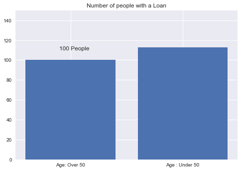

```python
D = {"Age : Under 50": 113, "Age: Over 50": 100}

plt.bar(range(len(D)), D.values(), align='center')
plt.xticks(range(len(D)), D.keys())


#plt.hist(Right.prob, bins, alpha=0.5, normed = True, label='true positives')
plt.title("Number of people with a Loan")
plt.ylim([0,150])
plt.text(-0.1,110,'100 People',rotation=0 )
plt.savefig('Over50.png', bbox_inches='tight')
plt.show()
```

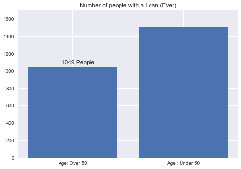

```python
D = {"Age : Under 50": len(under50LoanEver), "Age: Over 50": len(over50LoanEver)}

plt.bar(range(len(D)), D.values(), align='center')
plt.xticks(range(len(D)), D.keys())


#plt.hist(Right.prob, bins, alpha=0.5, normed = True, label='true positives')
plt.title("Number of people with a Loan (Ever)")
plt.ylim([0,1700])
plt.text(-0.1,len(over50LoanEver)+30,str(len(over50LoanEver))+' People',rotation=0 )
plt.savefig('Over50Ever.png', bbox_inches='tight')
plt.show()
```

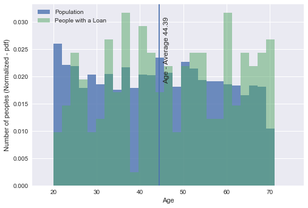

```python
bins = np.linspace(18, 75, 30)

plt.hist(JoinTest["Age"], bins, alpha=0.8, normed = True, label='Population')

plt.hist(JoinTest.ix[JoinTest["Loan Flag"] == 1, "Age"], bins, alpha=0.5, normed = True, label='People with a Loan')
plt.xlabel("Age")
plt.ylabel("Number of peoples (Normalized - pdf)")

#plt.hist(Right.prob, bins, alpha=0.5, normed = True, label='true positives')
plt.axvline(JoinTest["Age"].mean())
plt.text(JoinTest["Age"].mean()+1,0.030,'Age - Average '+str(np.round(JoinTest["Age"].mean(),2)),rotation=90, )
plt.legend()
plt.savefig('AgeDistribution.png', bbox_inches='tight')
plt.show()
```

The age is surely a factor. For young people should not be so easy to obtain a loan.

```python
female3040Products3 = JoinTest[(JoinTest["Age"] >= 30) & (JoinTest["Age"] <= 40) & (JoinTest["Gender"] == 0)]
female3040Products3 = female3040Products3[female3040Products3["ProductsAmount"] > 2]
```

```python
len(female3040Products3)
```

```
622
```

```python
female3040 = JoinTest[(JoinTest["Age"] >= 30) & (JoinTest["Age"] <= 40) & (JoinTest["Gender"] == 0)]
```

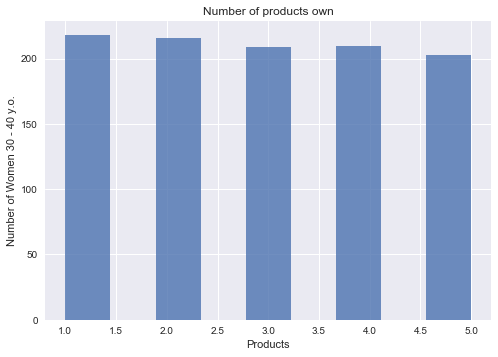

```python
bins = np.linspace(1, 5, 10)

plt.hist(female3040["ProductsAmount"], bins, alpha=0.8, normed = False, label='Female 30-40 y.o.')


plt.xlabel("Products")
plt.ylabel("Number of Women 30 - 40 y.o.")
#plt.ylabel("Number of peoples (Normalized - pdf)")
#plt.xticks(range(len(D)), [,1,,2,,3,,4,,5])

plt.title("Number of products own")
#plt.hist(Right.prob, bins, alpha=0.5, normed = True, label='true positives')
#plt.axvline(JoinTest["Age"].mean())
#plt.text(JoinTest["Age"].mean()+1,0.030,'Age - Average '+str(np.round(JoinTest["Age"].mean(),2)),rotation=90, )
plt.savefig('ProductsDistr.png', bbox_inches='tight')
plt.show()
```

```python
malesPreviousLoan = JoinTest[(JoinTest['Gender'] == 1) & (JoinTest["Held Loan previously"] == 1)]
malesPreviousLoan.head()
```

|  | Client ID | Age | Gender | County | Income Group | SNo | Population | Density (/ km2) | Rank | Province | ... | Held Loan previously | ProductsAmount | Client_x | Num Transactions | Last TXN Amount | Merchant Code | Last Transaction Narrative | Client_y | TxnAmount | Loan Flag |
| --- | --- | --- | --- | --- | --- | --- | --- | --- | --- | --- | --- | --- | --- | --- | --- | --- | --- | --- | --- | --- | --- |
| 0 | 1.0 | 36.0 | 1.0 | Cork | 10001 - 40000 | 4.0 | 519032.0 | 69.0 | 4.0 | Munster | ... | 1.0 | 4.0 | 1.0 | 0.0 | NaN | NaN | NaN | 1.0 | 58.0 | 0.0 |
| 3 | 37.0 | 21.0 | 1.0 | Cork | 10001 - 40000 | 4.0 | 519032.0 | 69.0 | 4.0 | Munster | ... | 1.0 | 1.0 | 37.0 | 4.0 | 247.65 | 4468.0 | MARINE SUPPLIERS DUBLIN | 37.0 | 28.0 | 0.0 |
| 11 | 70.0 | 42.0 | 1.0 | Cork | 10001 - 40000 | 4.0 | 519032.0 | 69.0 | 4.0 | Munster | ... | 1.0 | 4.0 | 70.0 | 15.0 | 886.13 | 5966.0 | AVGWELLNES441618501835 NICOSIA | 70.0 | 707.0 | 0.0 |
| 12 | 74.0 | 66.0 | 1.0 | Cork | 40001 - 60000 | 4.0 | 519032.0 | 69.0 | 4.0 | Munster | ... | 1.0 | 5.0 | 74.0 | 0.0 | NaN | NaN | NaN | 74.0 | 0.0 | 0.0 |
| 14 | 85.0 | 28.0 | 1.0 | Cork | 10001 - 40000 | 4.0 | 519032.0 | 69.0 | 4.0 | Munster | ... | 1.0 | 3.0 | 85.0 | 11.0 | 657.52 | 3389.0 | AVIS BIRMINGHAM E211889941 | 85.0 | 0.0 | 0.0 |

5 rows × 21 columns

```python
malesPreviousLoan["Num Transactions"].mean()
```

```
18.6544
```

```python
malesPreviousLoanMean = JoinTest.ix[(JoinTest['Gender'] == 1) & (JoinTest["Held Loan previously"] == 1), "Num Transactions"].mean()
print(malesPreviousLoanMean)
```

```
18.6544
```

```python
femalesPreviousLoanMean = JoinTest.ix[(JoinTest['Gender'] == 0) & (JoinTest["Held Loan previously"] == 1), "Num Transactions"].mean()
femalesPreviousLoanMean
```

```
17.207336523125996
```

```python
malesNoPreviousLoanMean = JoinTest.ix[(JoinTest['Gender'] == 1) & (JoinTest["Held Loan previously"] == 0), "Num Transactions"].mean()
malesNoPreviousLoanMean
```

```
18.636742128545407
```

```python
femalesNoPreviousLoanMean = JoinTest.ix[(JoinTest['Gender'] == 0) & (JoinTest["Held Loan previously"] == 0), "Num Transactions"].mean()
femalesNoPreviousLoanMean
```

```
18.168717528028438
```

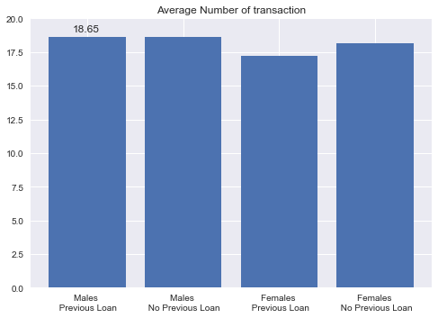

```python
keys = ["Males \n Previous Loan","Males \n No Previous Loan", "Females \n Previous Loan", "Females \n No Previous Loan"]
values = [malesPreviousLoanMean,malesNoPreviousLoanMean,femalesPreviousLoanMean,femalesNoPreviousLoanMean]
plt.text(-0.15,19,np.round(malesPreviousLoanMean,2),rotation=0 )
plt.bar(range(len(values)), values, align='center')
plt.xticks(range(len(keys)), keys)


#plt.hist(Right.prob, bins, alpha=0.5, normed = True, label='true positives')
plt.title("Average Number of transaction")
plt.ylim([0,20])

plt.savefig('TransactionsLoanMales.png', bbox_inches='tight')

plt.show()
```

```python
femaleNoLoan20 = JoinTest[(JoinTest["Age"] <= 20) & (JoinTest["Held Loan previously"] ==0) & (JoinTest["Gender"] == 0)]
femaleNoLoan2140 = JoinTest[(JoinTest["Age"] > 20) & (JoinTest["Age"] <= 40) &(JoinTest["Held Loan previously"] ==0) & (JoinTest["Gender"] == 0)]
femaleNoLoan40 = JoinTest[(JoinTest["Age"] > 40) & (JoinTest["Held Loan previously"] ==0) & (JoinTest["Gender"] == 0)]
```

```python
len(femaleNoLoan20)
```

```
120
```

```python
len(femaleNoLoan2140)
```

```
1534
```

```python
len(femaleNoLoan40)
```

```
2003
```

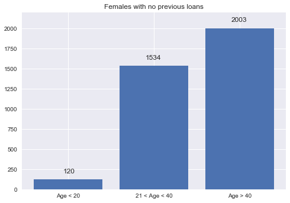

```python
D = {"Age < 20": len(femaleNoLoan20), "21 < Age < 40": len(femaleNoLoan2140), "Age > 40": len(femaleNoLoan40)}

keys = ["Age < 20", "21 < Age < 40", "Age > 40"]
values = [len(femaleNoLoan20),len(femaleNoLoan2140),len(femaleNoLoan40)]

plt.bar(range(len(D)), values, align='center')
plt.xticks(range(len(D)), keys)


#plt.hist(Right.prob, bins, alpha=0.5, normed = True, label='true positives')
plt.title("Females with no previous loans")
plt.ylim([0,2200])
#plt.text(-0.05,20,'100 People',rotation=0 )
plt.text(-0.055,200,len(femaleNoLoan20),rotation=0 )
plt.text(0.90,len(femaleNoLoan2140)+80,len(femaleNoLoan2140),rotation=0 )
plt.text(1.90,len(femaleNoLoan40)+80,len(femaleNoLoan40),rotation=0 )
#plt.text(-0.15,19,np.round(malesPreviousLoanMean,2),rotation=0 )
#plt.text(-0.15,19,np.round(malesPreviousLoanMean,2),rotation=0 )
plt.savefig('WomenNoLoans.png', bbox_inches='tight')
plt.show()
```

Predictive modelling

Now we will try to predict if a customer is going to ask for a loan. Before proceeding we have to clean and analyze the dataset

Let's create a copy of the data.

```python
JoinTraining = JoinTest.copy()
JoinTraining.head()
```

|  | Client ID | Age | Gender | County | Income Group | SNo | Population | Density (/ km2) | Rank | Province | ... | Held Loan previously | ProductsAmount | Client_x | Num Transactions | Last TXN Amount | Merchant Code | Last Transaction Narrative | Client_y | TxnAmount | Loan Flag |
| --- | --- | --- | --- | --- | --- | --- | --- | --- | --- | --- | --- | --- | --- | --- | --- | --- | --- | --- | --- | --- | --- |
| 0 | 1.0 | 36.0 | 1.0 | Cork | 10001 - 40000 | 4.0 | 519032.0 | 69.0 | 4.0 | Munster | ... | 1.0 | 4.0 | 1.0 | 0.0 | NaN | NaN | NaN | 1.0 | 58.0 | 0.0 |
| 1 | 9.0 | 24.0 | 0.0 | Cork | 60001 - 100000 | 4.0 | 519032.0 | 69.0 | 4.0 | Munster | ... | 0.0 | 4.0 | 9.0 | 5.0 | 45.00 | 5972.0 | DUBLIN MINT OFFICE LONDON | 9.0 | 22.0 | 0.0 |
| 2 | 24.0 | 57.0 | 1.0 | Cork | 10001 - 40000 | 4.0 | 519032.0 | 69.0 | 4.0 | Munster | ... | 0.0 | 2.0 | 24.0 | 11.0 | 890.00 | 5192.0 | EASONS KILKENNY CO DUBLIN | 24.0 | 0.0 | 0.0 |
| 3 | 37.0 | 21.0 | 1.0 | Cork | 10001 - 40000 | 4.0 | 519032.0 | 69.0 | 4.0 | Munster | ... | 1.0 | 1.0 | 37.0 | 4.0 | 247.65 | 4468.0 | MARINE SUPPLIERS DUBLIN | 37.0 | 28.0 | 0.0 |
| 4 | 38.0 | 60.0 | 0.0 | Cork | 100000+ | 4.0 | 519032.0 | 69.0 | 4.0 | Munster | ... | 0.0 | 4.0 | 38.0 | 9.0 | 220.27 | 3420.0 | ENTERPRISE GUERIN RENT FARO | 38.0 | 0.0 | 0.0 |

5 rows × 21 columns

Delete what would hardly help us in the classification task. We will take into account some of these features later (if we have time)

```python
JoinTraining = JoinTraining[JoinTraining.columns.difference(["SNo","Client_x","Client_y","Last Transaction Narrative","Province","Merchant Code"])]
```

```python
JoinTraining[JoinTraining["Population"].isnull()]
```

|  | Age | Change | Client ID | County | Density (/ km2) | Gender | Held Loan previously | Income Group | Last TXN Amount | Loan Flag | Num Transactions | Population | ProductsAmount | Rank | TxnAmount |
| --- | --- | --- | --- | --- | --- | --- | --- | --- | --- | --- | --- | --- | --- | --- | --- |
| 9980 | 65.0 | NaN | 267.0 | Navan | NaN | 1.0 | 0.0 | 10001 - 40000 | NaN | 0.0 | 0.0 | NaN | 2.0 | NaN | 864.0 |
| 9981 | 37.0 | NaN | 323.0 | Borris | NaN | 1.0 | 0.0 | 10001 - 40000 | 740.69 | 0.0 | 17.0 | NaN | 2.0 | NaN | 1418.0 |
| 9982 | 66.0 | NaN | 381.0 | Sandyford | NaN | 1.0 | 0.0 | 10001 - 40000 | 790.51 | 0.0 | 1.0 | NaN | 5.0 | NaN | 0.0 |
| 9983 | 43.0 | NaN | 524.0 | Maynooth | NaN | 0.0 | 1.0 | 10001 - 40000 | 616.98 | 1.0 | 95.0 | NaN | 5.0 | NaN | 93.0 |
| 9984 | 49.0 | NaN | 569.0 | Portlaoise | NaN | 1.0 | 0.0 | 40001 - 60000 | NaN | 0.0 | 0.0 | NaN | 3.0 | NaN | 377.0 |
| 9985 | 37.0 | NaN | 654.0 | Trim | NaN | 1.0 | 0.0 | 100000+ | NaN | 0.0 | 0.0 | NaN | 5.0 | NaN | 331.0 |
| 9986 | 59.0 | NaN | 721.0 | Ballina | NaN | 1.0 | 0.0 | 60001 - 100000 | 79.76 | 0.0 | 3.0 | NaN | 3.0 | NaN | 0.0 |
| 9987 | 24.0 | NaN | 867.0 | Spain | NaN | 0.0 | 0.0 | 10001 - 40000 | 132.62 | 0.0 | 6.0 | NaN | 2.0 | NaN | 209.0 |
| 9988 | 64.0 | NaN | 1080.0 | Sligo Town | NaN | 0.0 | 0.0 | 10001 - 40000 | 862.78 | 0.0 | 2.0 | NaN | 3.0 | NaN | 419.0 |
| 9989 | 34.0 | NaN | 1289.0 | Rosslare | NaN | 1.0 | 0.0 | 100000+ | 327.11 | 0.0 | 40.0 | NaN | 1.0 | NaN | 0.0 |
| 9990 | 28.0 | NaN | 1331.0 | Northern Ireland | NaN | 1.0 | 0.0 | 10001 - 40000 | 621.03 | 0.0 | 26.0 | NaN | 1.0 | NaN | 2185.0 |
| 9991 | 60.0 | NaN | 1407.0 | Lahinch | NaN | 0.0 | 0.0 | 60001 - 100000 | 317.29 | 0.0 | 40.0 | NaN | 4.0 | NaN | 1752.0 |
| 9992 | 23.0 | NaN | 1626.0 | Adare | NaN | 1.0 | 0.0 | 60001 - 100000 | 170.27 | 0.0 | 7.0 | NaN | 2.0 | NaN | 0.0 |
| 9993 | 33.0 | NaN | 7461.0 | Boyle | NaN | 0.0 | 1.0 | 10001 - 40000 | 553.73 | 0.0 | 1.0 | NaN | 4.0 | NaN | 2064.0 |
| 9994 | 24.0 | NaN | 7618.0 | Co. Kerry | NaN | 1.0 | 0.0 | 10001 - 40000 | NaN | 0.0 | 0.0 | NaN | 4.0 | NaN | 36.0 |
| 9995 | 65.0 | NaN | 7935.0 | 999 | NaN | 1.0 | 1.0 | 10001 - 40000 | 399.95 | 0.0 | 56.0 | NaN | 4.0 | NaN | 402.0 |
| 9996 | 28.0 | NaN | 8099.0 | 999 | NaN | 0.0 | 0.0 | 60001 - 100000 | 430.75 | 0.0 | 53.0 | NaN | 2.0 | NaN | 1099.0 |
| 9997 | 55.0 | NaN | 8201.0 |  | NaN | 1.0 | 0.0 | 60001 - 100000 | NaN | 0.0 | 0.0 | NaN | 3.0 | NaN | 440.0 |
| 9998 | 27.0 | NaN | 8297.0 | County Mayo | NaN | 1.0 | 0.0 | 40001 - 60000 | NaN | 0.0 | 0.0 | NaN | 5.0 | NaN | 0.0 |
| 9999 | 38.0 | NaN | 8631.0 | kildare Town | NaN | 0.0 | 0.0 | 60001 - 100000 | NaN | 0.0 | 0.0 | NaN | 1.0 | NaN | 361.0 |
| 10000 | 36.0 | NaN | 8653.0 | clare | NaN | 0.0 | 0.0 | 10001 - 40000 | 370.74 | 0.0 | 26.0 | NaN | 3.0 | NaN | 0.0 |
| 10001 | 33.0 | NaN | 8746.0 | leitrim | NaN | 0.0 | 0.0 | 10001 - 40000 | NaN | 0.0 | 0.0 | NaN | 1.0 | NaN | 0.0 |
| 10002 | 65.0 | NaN | 8815.0 | offaly | NaN | 0.0 | 0.0 | 10001 - 40000 | NaN | 0.0 | 0.0 | NaN | 2.0 | NaN | 1661.0 |
| 10003 | 43.0 | NaN | 8841.0 | Kildare town | NaN | 0.0 | 0.0 | 60001 - 100000 | 886.64 | 0.0 | 14.0 | NaN | 3.0 | NaN | 0.0 |

This time we have to remove these people beacuse of the NaN in the features that we will probably include in our model

```python
JoinTraining = JoinTraining[np.logical_not(JoinTraining["Population"].isnull())]
```

```python
JoinTraining['Income Group'].unique()
```

```
array([u'10001 - 40000', u'60001 - 100000', u'100000+', u'0 - 10000',
       u'40001 - 60000'], dtype=object)
```

This feature is categorical but at the same time represents a range binning over a numerical features. Let's reverse it back to be numerical

```python
JoinTraining.ix[JoinTraining['Income Group'] == "0 - 10000", "Income Group"] = 1
JoinTraining.ix[JoinTraining['Income Group'] == "10001 - 40000", "Income Group"] = 2
JoinTraining.ix[JoinTraining['Income Group'] == "40001 - 60000", "Income Group"] = 3
JoinTraining.ix[JoinTraining['Income Group'] == "60001 - 100000", "Income Group"] = 4
JoinTraining.ix[JoinTraining['Income Group'] == "100000+", "Income Group"] = 5
JoinTraining['Income Group'] = map (lambda x: int(x), JoinTraining['Income Group'])
```

The field of the last transaction is empty for people with no transactions. However, this could be usefull. Fill it with 0 (consistent)

```python
JoinTraining["Last TXN Amount"] = JoinTraining["Last TXN Amount"].fillna(0)
```

Measure the correlation among features to exclude the most correlated ones

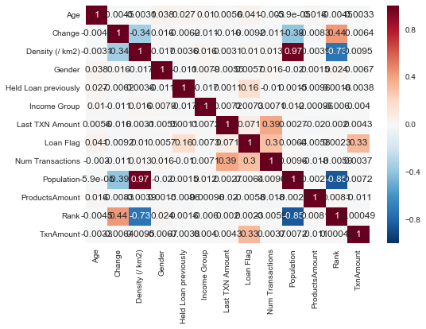

```python
corr = JoinTraining[JoinTraining.columns.difference(['County','Client ID'])].corr()

_ = sns.heatmap(corr, annot = True)
plt.savefig('Corr.png', bbox_inches='tight')
plt.show()
```

The information related to the counties are quite correlated. Let's keep just Density that is the most important for our Loan Flag

```python
JoinTraining = JoinTraining[JoinTraining.columns.difference(["Rank","Population","Change"])]
```

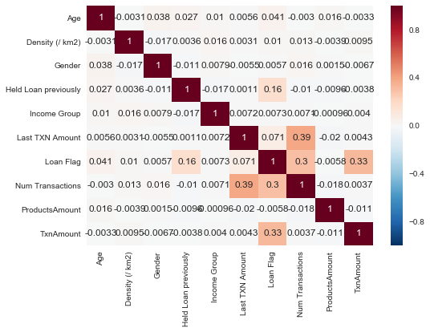

```python
corr = JoinTraining[JoinTraining.columns.difference(['County','Client ID'])].corr()

_ = sns.heatmap(corr, annot = True)
plt.savefig('Corr2.png', bbox_inches='tight')
plt.show()
```

Let's define the attributes for fitting and the class to be predicted.

```python
X = JoinTraining[JoinTraining.columns.difference(['County','Client ID','Loan Flag'])]
Y = JoinTraining['Loan Flag']
```

Define the train and the test with a ratio of 0.8 and 0.2 of the initial data

```python
from sklearn.model_selection import train_test_split
X_train,X_test,Y_train,Y_test = train_test_split(X,Y, random_state = 42, test_size = 0.2)
```

Import the models that we will test. I usually give always a try to Logistic Regression, Decision Tree (and Random Forest). However, since in this case the records are not so many and the class to predict is a binary label, I have quite high expectations even for Linear SVM.

```python
from sklearn.model_selection import KFold
from sklearn.model_selection import cross_val_score
from sklearn.linear_model import LogisticRegression
from sklearn.naive_bayes import GaussianNB
from sklearn.neighbors import KNeighborsClassifier
from sklearn.tree import DecisionTreeClassifier
from sklearn.svm import SVC, LinearSVC
from sklearn.ensemble import RandomForestClassifier

models = []
models.append(("LRegression",LogisticRegression()))
models.append(("NaiveBayesian",GaussianNB()))
models.append(("KNN",KNeighborsClassifier()))
models.append(("DTree",DecisionTreeClassifier()))
models.append(("RForest",RandomForestClassifier()))
```

We will try all these models with cross validation (10 splits)

```
('LRegression', 0.99160746045338632)
('NaiveBayesian', 0.9887257254525551)
('KNN', 0.98133631952220968)
('DTree', 0.99386184484992202)
('RForest', 0.99173324424954745)
```

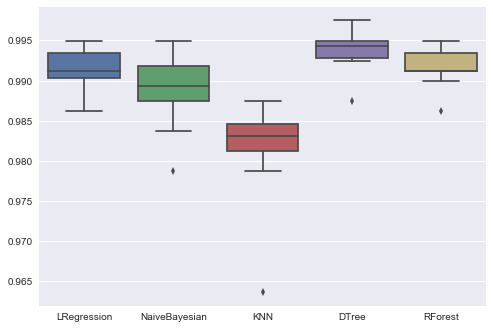

```python
results = []
names = []
for name,model in models:
    kfold = KFold(n_splits=10, random_state=42)
    cv_result = cross_val_score(model,X_train,Y_train, cv = kfold,scoring = "accuracy")
    names.append(name)
    results.append(cv_result)
for i in range(len(names)):
    print(names[i],results[i].mean())

ax = sns.boxplot(data=results)
ax.set_xticklabels(names)
plt.savefig('AccInitial', bbox_inches='tight')
plt.show()
```

Ok. What is going on here?

1. At a first sight, we could think that we should be very happy! However, this very high values are biased by the unbalance of the classes.
2. Since some of the models assume Gaussian features centered in 0. We should transpose them to have better results with these models (e.g., SVM)

```python
1 - Y.sum()/Y.count()
```

```
0.9789579158316634
```

If we always predict "NO", we will reach an accuracy of almost 98%! The classes are very unbalanced and hence we should be pay more attention to pay and evaluate our models. First, we should take into account not accuracy but the precision and the recall of the single classes. Accuracy could be easily overwhelmed by the huge number of zeros.

```
('LRegression', 0.63800727780990929)
('NaiveBayesian', 0.81024455369192216)
('KNN', 0.17920107962213225)
('DTree', 0.81388167534220168)
('RForest', 0.7102808463466358)
```

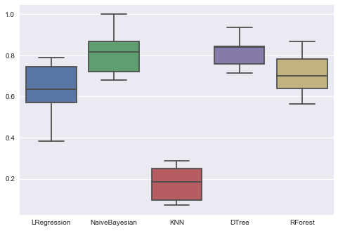

```python
results = []
names = []
for name,model in models:
    kfold = KFold(n_splits=10, random_state=42)
    cv_result = cross_val_score(model,X_train,Y_train, cv = kfold,scoring = "recall")
    names.append(name)
    results.append(cv_result)
for i in range(len(names)):
    print(names[i],results[i].mean())

ax = sns.boxplot(data=results)
ax.set_xticklabels(names)
plt.savefig('RecInitial.png', bbox_inches='tight')
plt.show()
```

```
('SVM', 0.9200200501253134)
('LSVM', 0.95990476190476193)
```

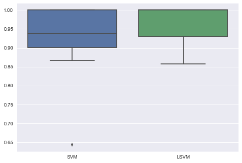

```python
from sklearn.preprocessing import StandardScaler

X = JoinTraining[JoinTraining.columns.difference(['County','Client ID','Loan Flag'])]
Y = JoinTraining['Loan Flag']

rescaledX = StandardScaler().fit_transform(X)

X_train_rescaled,X_test_rescaled,Y_train,Y_test = train_test_split(rescaledX,Y, random_state = 42, test_size = 0.2)

models = []
models.append(("SVM",SVC()))
models.append(("LSVM",LinearSVC()))

results = []
names = []
for name,model in models:
    kfold = KFold(n_splits=10, random_state=42)
    cv_result = cross_val_score(model,X_train_rescaled,Y_train, cv = kfold,scoring = "recall")
    names.append(name)
    results.append(cv_result)
for i in range(len(names)):
    print(names[i],results[i].mean())
ax = sns.boxplot(data=results)
ax.set_xticklabels(names)
plt.savefig('RecInitialNorm.png', bbox_inches='tight')
plt.show()
```

Second, since none of these techniques fit such unbalanced use cases, maybe we should re-train the models with a slightly modified datasets, in which we subsample the majority class (or oversample the minority one).

Let's start from the beginning with a brand new oversampled and undersampled copy of the dataset. Do not forget to work just on the training set for the resampling, to avoid overfitting.

```python
Xcol = JoinTraining.columns.difference(['County','Client ID','Loan Flag'])
Ycol = 'Loan Flag'
X = JoinTraining[Xcol]
Y = JoinTraining[Ycol]
X_train, X_test, Y_train, Y_test = train_test_split(X,Y, random_state = 42, test_size = 0.2)

rescaledX = X.copy()
rescaledX[rescaledX.columns] = StandardScaler().fit_transform(rescaledX[X.columns])
X_train_rescaled, X_test_rescaled, Y_train_rescaled, Y_test_rescaled = train_test_split(rescaledX,Y, random_state = 42, test_size = 0.2)
```

```python
from imblearn.over_sampling import SMOTE

sm = SMOTE(random_state=12, ratio = 1.0)
X_train_res, Y_train_res = sm.fit_sample(X_train, Y_train)

X_train_res_rescaled, Y_train_res_rescaled = sm.fit_sample(X_train_rescaled, Y_train)
```

```python
pdtrain = X_train.copy()
pdtrain["Loan Flag"] = Y_train
pdtrainLoanN = pdtrain[pdtrain['Loan Flag'] == 0].sample(len(pdtrain[pdtrain['Loan Flag'] == 1]))
pdtrainLoanY = pdtrain[pdtrain['Loan Flag'] == 1]
pdtrain = pd.concat([pdtrainLoanN, pdtrainLoanY])
X_train_sub = pdtrain[pdtrain.columns.difference(["Loan Flag"])]
Y_train_sub = pdtrain["Loan Flag"]


pdtrainRescaled = X_train_rescaled.copy()
pdtrainRescaled["Loan Flag"] = Y_train_rescaled
pdtrainRescaledN = pdtrainRescaled[pdtrainRescaled['Loan Flag'] == 0].sample(len(pdtrainRescaled[pdtrainRescaled['Loan Flag'] == 1]))
pdtrainRescaledY = pdtrainRescaled[pdtrainRescaled['Loan Flag'] == 1]
pdtrainRescaled = pd.concat([pdtrainRescaledN, pdtrainRescaledY])
X_train_sub_rescaled = pdtrainRescaled[pdtrainRescaled.columns.difference(["Loan Flag"])]
Y_train_sub_rescaled = pdtrainRescaled["Loan Flag"]
```

```
undersampling
('SVM', 0.58750000000000002)
('LSVM', 0.58750000000000002)
```

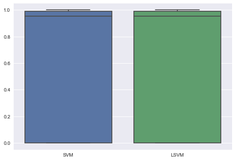

```
oversampling
('SVM', 0.98697520810314698)
('LSVM', 0.97929558937246974)
```

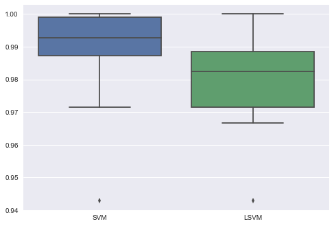

```python
models = []
models.append(("SVM",SVC()))
models.append(("LSVM",LinearSVC()))

results = []
names = []
for name,model in models:
    kfold = KFold(n_splits=10, random_state=42)
    cv_result = cross_val_score(model,X_train_sub_rescaled,Y_train_sub_rescaled, cv = kfold,scoring = "recall")
    names.append(name)
    results.append(cv_result)
print("undersampling")
for i in range(len(names)):
    print(names[i],results[i].mean())
ax = sns.boxplot(data=results)
ax.set_xticklabels(names)
plt.show()




results = []
names = []
for name,model in models:
    kfold = KFold(n_splits=10, random_state=42)
    cv_result = cross_val_score(model,X_train_res_rescaled,Y_train_res_rescaled, cv = kfold,scoring = "recall")
    names.append(name)
    results.append(cv_result)
print("oversampling")
for i in range(len(names)):
    print(names[i],results[i].mean())
ax = sns.boxplot(data=results)
ax.set_xticklabels(names)
plt.savefig('OverSVM.png', bbox_inches='tight')
plt.show()
```

```
undersampling
('LRegression', 0.58750000000000002)
('NaiveBayesian', 0.58750000000000002)
('DTree', 0.53125)
('RForest', 0.578125)
```

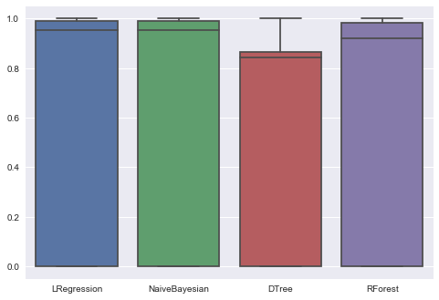

```
oversampling
('LRegression', 0.97133941685631819)
('NaiveBayesian', 0.9769522004715977)
('DTree', 0.94768589736034659)
('RForest', 0.93955778535074452)
```

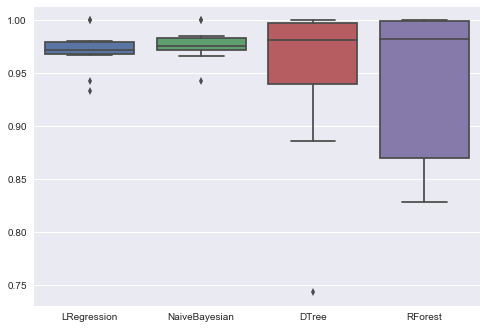

```python
models = []
models.append(("LRegression",LogisticRegression()))
models.append(("NaiveBayesian",GaussianNB()))
models.append(("DTree",DecisionTreeClassifier()))
models.append(("RForest",RandomForestClassifier()))

results = []
names = []
for name,model in models:
    kfold = KFold(n_splits=10, random_state=42)
    cv_result = cross_val_score(model,X_train_sub,Y_train_sub, cv = kfold,scoring = "recall")
    names.append(name)
    results.append(cv_result)
print("undersampling")
for i in range(len(names)):
    print(names[i],results[i].mean())
ax = sns.boxplot(data=results)
ax.set_xticklabels(names)
plt.savefig('underOther.png', bbox_inches='tight')
plt.show()


results = []
names = []
for name,model in models:
    kfold = KFold(n_splits=10, random_state=42)
    cv_result = cross_val_score(model,X_train_res,Y_train_res, cv = kfold,scoring = "recall")
    names.append(name)
    results.append(cv_result)
print("oversampling")
for i in range(len(names)):
    print(names[i],results[i].mean())
ax = sns.boxplot(data=results)
ax.set_xticklabels(names)
plt.savefig('overOther.png', bbox_inches='tight')
plt.show()
```

Some of them are very similar. In general we can just exclude some of them and pick a group of the best to be tested with the testing set. Let's start with a DT. Then test the random forest, Naive Bayesian, logistic regression and a linear SVM

```python
from sklearn.metrics import accuracy_score
from sklearn.metrics import classification_report
from sklearn.metrics import confusion_matrix
from sklearn.metrics import recall_score
from sklearn.metrics import precision_score


model = DecisionTreeClassifier()
model.fit(X_train_sub,Y_train_sub)
predictions = model.predict(X_test)

print("Subsampling")
print(classification_report(Y_test,predictions))


model = DecisionTreeClassifier()
model.fit(X_train_res,Y_train_res)
predictions = model.predict(X_test)

print("Oversampling")
print(classification_report(Y_test,predictions))

model = DecisionTreeClassifier()
model.fit(X_train,Y_train)
predictions = model.predict(X_test)
print("\nWhole training set")
print(classification_report(Y_test,predictions))
```

```
Subsampling
             precision    recall  f1-score   support

        0.0       1.00      0.94      0.97      1947
        1.0       0.27      0.90      0.41        49

avg / total       0.98      0.94      0.95      1996

Oversampling
             precision    recall  f1-score   support

        0.0       1.00      0.99      0.99      1947
        1.0       0.72      0.94      0.81        49

avg / total       0.99      0.99      0.99      1996


Whole training set
             precision    recall  f1-score   support

        0.0       1.00      1.00      1.00      1947
        1.0       0.86      0.88      0.87        49

avg / total       0.99      0.99      0.99      1996
```

```python
model = RandomForestClassifier()
model.fit(X_train_sub,Y_train_sub)
predictions = model.predict(X_test)

print("Subsampling")
print(classification_report(Y_test,predictions))


model = RandomForestClassifier()
model.fit(X_train_res,Y_train_res)
predictions = model.predict(X_test)

print("Oversampling")
print(classification_report(Y_test,predictions))

model = RandomForestClassifier()
model.fit(X_train,Y_train)
predictions = model.predict(X_test)
print("\nWhole training set")
print(classification_report(Y_test,predictions))
```

```
Subsampling
             precision    recall  f1-score   support

        0.0       1.00      0.95      0.98      1947
        1.0       0.34      0.96      0.50        49

avg / total       0.98      0.95      0.96      1996

Oversampling
             precision    recall  f1-score   support

        0.0       1.00      1.00      1.00      1947
        1.0       0.87      0.84      0.85        49

avg / total       0.99      0.99      0.99      1996


Whole training set
             precision    recall  f1-score   support

        0.0       0.99      1.00      1.00      1947
        1.0       0.97      0.73      0.84        49

avg / total       0.99      0.99      0.99      1996
```

```python
DT = LinearSVC()
model.fit(X_train_sub_rescaled,Y_train_sub_rescaled)
predictions = model.predict(X_test_rescaled)

print("Subsampling")
print(classification_report(Y_test_rescaled,predictions))

DT = LinearSVC()
model.fit(X_train_res_rescaled,Y_train_res_rescaled)
predictions = model.predict(X_test_rescaled)

print("Oversampling")
print(classification_report(Y_test_rescaled,predictions))

DT = LinearSVC()
model.fit(X_train_rescaled,Y_train_rescaled)
predictions = model.predict(X_test_rescaled)
print("\nWhole training set")
print(classification_report(Y_test_rescaled,predictions))
```

```
Subsampling
             precision    recall  f1-score   support

        0.0       1.00      0.97      0.99      1947
        1.0       0.48      0.96      0.64        49

avg / total       0.99      0.97      0.98      1996

Oversampling
             precision    recall  f1-score   support

        0.0       1.00      1.00      1.00      1947
        1.0       0.87      0.82      0.84        49

avg / total       0.99      0.99      0.99      1996


Whole training set
             precision    recall  f1-score   support

        0.0       0.99      1.00      1.00      1947
        1.0       0.92      0.71      0.80        49

avg / total       0.99      0.99      0.99      1996
```

```python
model = GaussianNB()
model.fit(X_train_sub,Y_train_sub)
predictions = model.predict(X_test)

print("Subsampling")
print(classification_report(Y_test,predictions))


model = GaussianNB()
model.fit(X_train_res,Y_train_res)
predictions = model.predict(X_test)

print("Oversampling")
print(classification_report(Y_test,predictions))

model = GaussianNB()
model.fit(X_train,Y_train)
predictions = model.predict(X_test)
print("\nWhole training set")
print(classification_report(Y_test,predictions))
```

```
Subsampling
             precision    recall  f1-score   support

        0.0       1.00      0.89      0.94      1947
        1.0       0.18      0.96      0.30        49

avg / total       0.98      0.89      0.92      1996

Oversampling
             precision    recall  f1-score   support

        0.0       1.00      0.92      0.96      1947
        1.0       0.23      0.96      0.37        49

avg / total       0.98      0.92      0.94      1996


Whole training set
             precision    recall  f1-score   support

        0.0       0.99      1.00      0.99      1947
        1.0       0.80      0.71      0.75        49

avg / total       0.99      0.99      0.99      1996
```

```python
model = LogisticRegression()
model.fit(X_train_sub,Y_train_sub)
predictions = model.predict(X_test)

print("Subsampling")
print(classification_report(Y_test,predictions))

model = LogisticRegression()
model.fit(X_train_res,Y_train_res)
predictions = model.predict(X_test)

print("Oversampling")
print(classification_report(Y_test,predictions))

model = LogisticRegression()
model.fit(X_train,Y_train)
predictions = model.predict(X_test)
print("\nWhole training set")
print(classification_report(Y_test,predictions))
```

```
Subsampling
             precision    recall  f1-score   support

        0.0       1.00      0.92      0.96      1947
        1.0       0.24      0.96      0.38        49

avg / total       0.98      0.92      0.95      1996

Oversampling
             precision    recall  f1-score   support

        0.0       1.00      0.96      0.98      1947
        1.0       0.37      0.96      0.54        49

avg / total       0.98      0.96      0.97      1996


Whole training set
             precision    recall  f1-score   support

        0.0       0.99      1.00      1.00      1947
        1.0       0.95      0.78      0.85        49

avg / total       0.99      0.99      0.99      1996
```

The random forest and Logistic regression seem the most promising.

Now we have to decide. Do we want something generally accurate or we have some specific requirements? I really want to give more attentions to the customers with a loan, wanting to be able to predict all of them even at the cost of being to much generous with this class assignment.

If we were interested to general accuracy, we would have used not the undersampled training set. In this way, we could have detected just the majority of the true positives, however with much less false positives.

The choicse depends on the business. In this specific case I prefer not to miss any true positive. Go ahead with the subsampling. Try to tune the forest.

```python
sample_leaf_options = [1,5,10,25,50,100]
for leaf_size in sample_leaf_options :
    model = RandomForestClassifier(n_estimators = 100,  n_jobs = -1,random_state =50,  max_features = "auto", min_samples_leaf = leaf_size)
    model.fit(X_train_sub,Y_train_sub)
    predictions = model.predict(X_test)
    print leaf_size
    print "recall : ", recall_score(Y_test,predictions)
    print "precision : ", precision_score(Y_test,predictions)
```

```
1
recall :  0.959183673469
precision :  0.284848484848
5
recall :  0.959183673469
precision :  0.22380952381
10
recall :  0.959183673469
precision :  0.200854700855
25
recall :  0.959183673469
precision :  0.18875502008
50
recall :  0.959183673469
precision :  0.164912280702
100
recall :  0.877551020408
precision :  0.0957683741648
```

```python
estimators = [1,5,10,25,50,100,150,200,500]
for estimator in estimators :
    model = RandomForestClassifier(n_estimators = estimator, n_jobs = -1,random_state =50,  max_features = "auto", min_samples_leaf = 1)
    model.fit(X_train_sub,Y_train_sub)
    predictions = model.predict(X_test)
    print estimator
    print "recall : ", recall_score(Y_test,predictions)
    print "precision : ", precision_score(Y_test,predictions)
```

```
1
recall :  0.857142857143
precision :  0.121037463977
5
recall :  0.938775510204
precision :  0.270588235294
10
recall :  0.918367346939
precision :  0.31914893617
25
recall :  0.959183673469
precision :  0.307189542484
50
recall :  0.959183673469
precision :  0.278106508876
100
recall :  0.959183673469
precision :  0.284848484848
150
recall :  0.959183673469
precision :  0.315436241611
200
recall :  0.959183673469
precision :  0.311258278146
500
recall :  0.959183673469
precision :  0.335714285714
```

```python
features = np.arange(1,10)
for n in features :
    model = RandomForestClassifier(n_estimators = 200, n_jobs = -1,random_state =50,  max_features = n, min_samples_leaf = 1)
    model.fit(X_train_sub,Y_train_sub)
    predictions = model.predict(X_test)
    print n
    print "recall : ", recall_score(Y_test,predictions)
    print "precision : ", precision_score(Y_test,predictions)
```

```
1
recall :  0.959183673469
precision :  0.255434782609
2
recall :  0.959183673469
precision :  0.271676300578
3
recall :  0.959183673469
precision :  0.311258278146
4
recall :  0.959183673469
precision :  0.324137931034
5
recall :  0.959183673469
precision :  0.350746268657
6
recall :  0.959183673469
precision :  0.338129496403
7
recall :  0.959183673469
precision :  0.345588235294
8
recall :  0.959183673469
precision :  0.343065693431
9
recall :  0.959183673469
precision :  0.311258278146
```

```python
model = RandomForestClassifier(n_estimators = 150, n_jobs = -1, random_state =50,  max_features = 7, min_samples_leaf = 1)
model.fit(X_train_sub,Y_train_sub)
predictions = model.predict(X_test)
print "recall : ", recall_score(Y_test,predictions)
print "precision : ", precision_score(Y_test,predictions)
```

```
recall :  0.959183673469
precision :  0.338129496403
```

Let's try with Logistic Regression'

```python
param=[0.001, 0.01, 0.1, 1, 10, 100, 1000]

for c in param :
    model = LogisticRegression(C=c, intercept_scaling=1, dual=False, fit_intercept=True,
          penalty='l2', tol=0.0001)
    model.fit(X_train_sub,Y_train_sub)
    predictions = model.predict(X_test)
    print n
    print "recall : ", recall_score(Y_test,predictions)
    print "precision : ", precision_score(Y_test,predictions)


param=[0.001, 0.01, 0.1, 1, 10, 100, 1000]
```

```
9
recall :  0.938775510204
precision :  0.129213483146
9
recall :  0.938775510204
precision :  0.145110410095
9
recall :  0.938775510204
precision :  0.175572519084
9
recall :  0.959183673469
precision :  0.239795918367
9
recall :  0.959183673469
precision :  0.307189542484
9
recall :  0.959183673469
precision :  0.321917808219
9
recall :  0.959183673469
precision :  0.315436241611
```

In the end we decided to use the Random Forest.

One last try. Since we have excluded the information about the county, which could be usefull, let's try to include it. Of course, since it is categorical, we should pay attention (even if we transform it into integers, we do not want that our algorithm think that they could be ordererd).

So we create a new (boolean) feature for each of the possible values.

```python
from sklearn.preprocessing import LabelEncoder, OneHotEncoder

one_hot = pd.get_dummies(JoinTest['County'])
JoinTrainingCat = JoinTraining.join(one_hot)

Xcolcat = JoinTraining.columns.difference(['County','Client ID','Loan Flag'])
Ycol = 'Loan Flag'
Xcat = JoinTraining[Xcolcat]
Y = JoinTraining[Ycol]
X_traincat, X_testcat, Y_traincat, Y_testcat = train_test_split(Xcat,Y, random_state = 42, test_size = 0.2)

sm = SMOTE(random_state=12, ratio = 1.0)
X_train_rescat, Y_train_rescat = sm.fit_sample(X_traincat, Y_traincat)

pdtraincat = X_traincat.copy()
pdtraincat["Loan Flag"] = Y_traincat
pdtraincatLoanN = pdtraincat[pdtraincat['Loan Flag'] == 0].sample(len(pdtraincat[pdtraincat['Loan Flag'] == 1]))
pdtraincatLoanY = pdtraincat[pdtraincat['Loan Flag'] == 1]
pdtraincat = pd.concat([pdtraincatLoanN, pdtraincatLoanY])
X_train_subcat = pdtraincat[pdtraincat.columns.difference(["Loan Flag"])]
Y_train_subcat = pdtraincat["Loan Flag"]

model = RandomForestClassifier(n_estimators = 150, n_jobs = -1, random_state =50,  max_features = 7, min_samples_leaf = 1)
model.fit(X_train_subcat,Y_train_subcat)
predictions = model.predict(X_test)
print "recall : ", recall_score(Y_test,predictions)
print "precision : ", precision_score(Y_test,predictions)
```

```
recall :  0.959183673469
precision :  0.484536082474
```

```python
model = RandomForestClassifier(n_estimators = 150, n_jobs = -1, random_state =50,  max_features = 7, min_samples_leaf = 1)
model.fit(X_train_sub,Y_train_sub)
predictions = model.predict(JoinTraining[JoinTraining.columns.difference(['County','Client ID','Loan Flag'])])
prob = model.predict_proba(JoinTraining[JoinTraining.columns.difference(['County','Client ID','Loan Flag'])])
print "recall : ", recall_score(JoinTraining["Loan Flag"],predictions)
print "precision : ", precision_score(JoinTraining["Loan Flag"],predictions)
```

```
recall :  0.990476190476
precision :  0.302765647744
```

```python
model_Final = model
```

```python
JoinTraining["loan_predicted"] = predictions
JoinTraining["prob"] = prob[:,1]
```

```python
JoinTraining.ix[JoinTraining["Loan Flag"]==1, ["Loan Flag","loan_predicted"]].head(10)
```

|  | Loan Flag | loan_predicted |
| --- | --- | --- |
| 25 | 1.0 | 1.0 |
| 76 | 1.0 | 1.0 |
| 95 | 1.0 | 1.0 |
| 131 | 1.0 | 1.0 |
| 176 | 1.0 | 1.0 |
| 249 | 1.0 | 1.0 |
| 511 | 1.0 | 1.0 |
| 538 | 1.0 | 1.0 |
| 577 | 1.0 | 1.0 |
| 581 | 1.0 | 1.0 |

```python
JoinTraining.ix[JoinTraining["loan_predicted"]==1, ["Loan Flag","loan_predicted"]].head(10)
```

|  | Loan Flag | loan_predicted |
| --- | --- | --- |
| 25 | 1.0 | 1.0 |
| 69 | 0.0 | 1.0 |
| 76 | 1.0 | 1.0 |
| 92 | 0.0 | 1.0 |
| 95 | 1.0 | 1.0 |
| 98 | 0.0 | 1.0 |
| 114 | 0.0 | 1.0 |
| 122 | 0.0 | 1.0 |
| 131 | 1.0 | 1.0 |
| 132 | 0.0 | 1.0 |

```python
Right = JoinTraining.ix[JoinTraining["loan_predicted"] == JoinTraining["Loan Flag"], ["Loan Flag","loan_predicted","prob"]]
Mistakes = JoinTraining.ix[JoinTraining["loan_predicted"] != JoinTraining["Loan Flag"], ["Loan Flag","loan_predicted","prob"]]
```

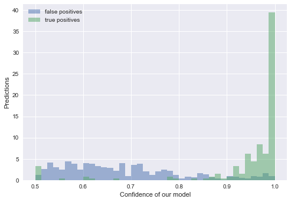

```python
bins = np.linspace(0.5, 1, 41)

plt.hist(Mistakes.prob, bins, alpha=0.5, normed = True, label='false positives')


plt.hist(Right.prob, bins, alpha=0.5, normed = True, label='true positives')
plt.xlabel("Confidence of our model")
plt.ylabel("Predictions")
plt.legend()
plt.savefig('Mistakes.png', bbox_inches='tight')
plt.show()
```

```python
x = 0.95
y = 1
sum(JoinTraining.ix[(JoinTraining["prob"] <= y) & (JoinTraining["prob"] > x), "Loan Flag"]) / len(JoinTraining[(JoinTraining["prob"] <= y) & (JoinTraining["prob"] > x)])
```

```
0.85483870967741937
```

```python
x = 0.90
y = 0.95
sum(JoinTraining.ix[(JoinTraining["prob"] <= y) & (JoinTraining["prob"] > x), "Loan Flag"]) / len(JoinTraining[(JoinTraining["prob"] <= y) & (JoinTraining["prob"] > x)])
```

```
0.70454545454545459
```

```python
x = 0.86
y =0.90
sum(JoinTraining.ix[(JoinTraining["prob"] <= y) & (JoinTraining["prob"] > x), "Loan Flag"]) / len(JoinTraining[(JoinTraining["prob"] <= y) & (JoinTraining["prob"] > x)])
```

```
0.44444444444444442
```

```python
x = 0.82
y = 0.86
sum(JoinTraining.ix[(JoinTraining["prob"] <= y) & (JoinTraining["prob"] > x), "Loan Flag"]) / len(JoinTraining[(JoinTraining["prob"] <= y) & (JoinTraining["prob"] > x)])
```

```
0.083333333333333329
```

```python
x = 0
y = 0.82
sum(JoinTraining.ix[(JoinTraining["prob"] <= y) & (JoinTraining["prob"] > x), "Loan Flag"]) / len(JoinTraining[(JoinTraining["prob"] <= y) & (JoinTraining["prob"] > x)])
```

```
0.0015342129487572874
```

```python
def classLike(x):
    if x<0.82 :
        return 1
    elif x>0.82 and x <= 0.86:
        return 2
    elif x>0.86 and x <= 0.90:
        return 3
    elif x>0.90 and x <= 0.95:
        return 4
    else:
        return 5
```

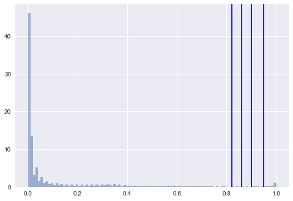

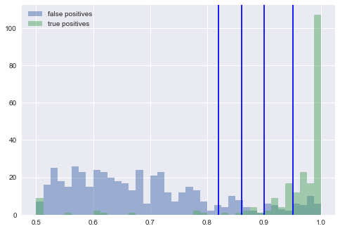

```python
bins = np.linspace(0, 1, 100)
plt.hist(JoinTraining.prob, bins, alpha=0.5, normed = True)
plt.axvline(0.82,color='b')
plt.axvline(0.86,color='b')
plt.axvline(0.90,color='b')
plt.axvline(0.95,color='b')
plt.show()


bins = np.linspace(0.5, 1, 41)
plt.hist(Mistakes.prob, bins, alpha=0.5, label='false positives')
plt.hist(Right.prob, bins, alpha=0.5, label='true positives')
plt.legend()
plt.axvline(0.82,color='b')
plt.axvline(0.86,color='b')
plt.axvline(0.90,color='b')
plt.axvline(0.95,color='b')
plt.savefig('thresholds.png', bbox_inches='tight')
plt.show()
```

```python
JoinTraining["Loan Likelihood"] = map (lambda x: classLike(x), JoinTraining["prob"])
```

Now we have the class feature for each customer.

```python
JoinTraining.head()
```

|  | Age | Client ID | County | Density (/ km2) | Gender | Held Loan previously | Income Group | Last TXN Amount | Loan Flag | Num Transactions | ProductsAmount | TxnAmount | loan_predicted | prob | Loan Likelihood |
| --- | --- | --- | --- | --- | --- | --- | --- | --- | --- | --- | --- | --- | --- | --- | --- |
| 0 | 36.0 | 1.0 | Cork | 69.0 | 1.0 | 1.0 | 2 | 0.00 | 0.0 | 0.0 | 4.0 | 58.0 | 0.0 | 0.000000 | 1 |
| 1 | 24.0 | 9.0 | Cork | 69.0 | 0.0 | 0.0 | 4 | 45.00 | 0.0 | 5.0 | 4.0 | 22.0 | 0.0 | 0.033333 | 1 |
| 2 | 57.0 | 24.0 | Cork | 69.0 | 1.0 | 0.0 | 2 | 890.00 | 0.0 | 11.0 | 2.0 | 0.0 | 0.0 | 0.313333 | 1 |
| 3 | 21.0 | 37.0 | Cork | 69.0 | 1.0 | 1.0 | 2 | 247.65 | 0.0 | 4.0 | 1.0 | 28.0 | 0.0 | 0.000000 | 1 |
| 4 | 60.0 | 38.0 | Cork | 69.0 | 0.0 | 0.0 | 5 | 220.27 | 0.0 | 9.0 | 4.0 | 0.0 | 0.0 | 0.013333 | 1 |

Let's prepare now the testing set. In this boring phase I will repeat the same analysis and transformation I did for the training sets. At the end I will use the model previously obtained to generate the predicted loading files. My Priority is to maximize the recall of the Loans. My model is not that prudent to assign 1, but it tends to hit all of them. The price is that it tends to assign 1 even when it should not, but this is a good tradeoff since the class were unbalanced. If I had more more, I would have tried oversampling instead of subsampling.

```python
DemographicsTest = pd.read_csv('Test - Demographics.csv', header=0, encoding='ISO-8859-15')
```

```python
DemographicsTest.head()
```

|  | Client ID | Age | Gender 1: Female, 2: Male | County | Income Group |
| --- | --- | --- | --- | --- | --- |
| 0 | 10001 | 59 | 1 | Cork | 10001 - 40000 |
| 1 | 10002 | 27 | 1 | Kerry | 10001 - 40000 |
| 2 | 10003 | 58 | 0 | Louth | 10001 - 40000 |
| 3 | 10004 | 45 | 1 | Dublin | 60001 - 100000 |
| 4 | 10005 | 21 | 0 | Dublin | 40001 - 60000 |

```python
DemographicsTest.describe()
```

|  | Client ID | Age | Gender 1: Female, 2: Male |
| --- | --- | --- | --- |
| count | 2000.000000 | 2000.000000 | 2000.000000 |
| mean | 11000.500000 | 48.386500 | 0.509000 |
| std | 577.494589 | 17.710193 | 0.500044 |
| min | 10001.000000 | 20.000000 | 0.000000 |
| 25% | 10500.750000 | 33.000000 | 0.000000 |
| 50% | 11000.500000 | 48.000000 | 1.000000 |
| 75% | 11500.250000 | 63.000000 | 1.000000 |
| max | 12000.000000 | 80.000000 | 1.000000 |

```python
DemographicsTest.columns
```

```
Index([u'Client ID', u'Age', u'Gender \n1: Female, 2: Male', u'County',
       u'Income Group'],
      dtype='object')
```

```python
DemographicsTest = DemographicsTest.rename(columns={'Gender \n1: Female, 2: Male' : "Gender"})
```

```python
DemographicsTest.groupby("Client ID").filter(lambda x: len(x) > 1)
```

|  | Client ID | Age | Gender | County | Income Group |
| --- | --- | --- | --- | --- | --- |

```python
DemographicsTest.Gender.unique()
```

```
array([1, 0], dtype=int64)
```

```python
DemographicsTest['Income Group'].unique()
```

```
array([u'10001 - 40000', u'60001 - 100000', u'40001 - 60000', u'0 - 10000',
       u'100000+'], dtype=object)
```

```python
DemographicsTest.ix[DemographicsTest['County'].str.contains("Dub"),"County"] = "Dublin"
DemographicsTest.ix[DemographicsTest['County'].str.contains("dub"),"County"] = "Dublin"
DemographicsTest.ix[DemographicsTest['County'].str.contains("blin"),"County"] = "Dublin"
DemographicsTest.ix[DemographicsTest['County'].str.contains("cork"),"County"] = "Cork"
DemographicsTest.ix[DemographicsTest['County'].str.contains("Cork"),"County"] = "Cork"
DemographicsTest.ix[DemographicsTest['County'].str.contains("ongford"),"County"] = "Longford"
```

```python
CountyTest = County.copy()
```

```python
PreviousLoanTest = pd.read_csv('Test - Previous Loan Holdings.csv', header=0)
PreviousLoanTest.head()
```

|  | Client ID | Held Loan previously | Unnamed: 2 | Unnamed: 3 | Unnamed: 4 | Unnamed: 5 | Unnamed: 6 | Unnamed: 7 | Unnamed: 8 | Unnamed: 9 | Unnamed: 10 | Unnamed: 11 | Unnamed: 12 | Unnamed: 13 |
| --- | --- | --- | --- | --- | --- | --- | --- | --- | --- | --- | --- | --- | --- | --- |
| 0 | 10001 | 0 | NaN | NaN | NaN | NaN | NaN | NaN | NaN | NaN | NaN | NaN | NaN | NaN |
| 1 | 10002 | 0 | NaN | NaN | NaN | NaN | NaN | NaN | NaN | NaN | NaN | NaN | NaN | NaN |
| 2 | 10003 | 0 | NaN | NaN | NaN | NaN | NaN | NaN | NaN | NaN | NaN | NaN | NaN | NaN |
| 3 | 10004 | 0 | NaN | NaN | NaN | NaN | NaN | NaN | NaN | NaN | NaN | NaN | NaN | NaN |
| 4 | 10005 | 0 | NaN | NaN | NaN | NaN | NaN | NaN | NaN | NaN | NaN | NaN | NaN | NaN |

```python
PreviousLoanTest.columns
```

```
Index([u'Client ID', u'Held Loan previously', u'Unnamed: 2', u'Unnamed: 3',
       u'Unnamed: 4', u'Unnamed: 5', u'Unnamed: 6', u'Unnamed: 7',
       u'Unnamed: 8', u'Unnamed: 9', u'Unnamed: 10', u'Unnamed: 11',
       u'Unnamed: 12', u'Unnamed: 13'],
      dtype='object')
```

```python
PreviousLoanTest = PreviousLoanTest[PreviousLoanTest.columns[0:2]]
PreviousLoanTest = PreviousLoanTest[0:2000]
PreviousLoanTest.head()
```

|  | Client ID | Held Loan previously |
| --- | --- | --- |
| 0 | 10001 | 0 |
| 1 | 10002 | 0 |
| 2 | 10003 | 0 |
| 3 | 10004 | 0 |
| 4 | 10005 | 0 |

```python
PreviousLoanTest.groupby("Client ID").filter(lambda x: len(x) > 1)
```

|  | Client ID | Held Loan previously |
| --- | --- | --- |

```python
PreviousLoanTest.describe()
```

|  | Client ID | Held Loan previously |
| --- | --- | --- |
| count | 2000.000000 | 2000.000000 |
| mean | 11000.500000 | 0.243500 |
| std | 577.494589 | 0.429302 |
| min | 10001.000000 | 0.000000 |
| 25% | 10500.750000 | 0.000000 |
| 50% | 11000.500000 | 0.000000 |
| 75% | 11500.250000 | 0.000000 |
| max | 12000.000000 | 1.000000 |

```python
BankProductsTest = pd.read_csv('Test - Product Held in Bank.csv', header=[0,1])
BankProductsTest.head()
```

|  | Unnamed: 0_level_0 Client ID | Unnamed: 1_level_0 # Products in bank | Unnamed: 2_level_0 Unnamed: 2_level_1 | Unnamed: 3_level_0 Unnamed: 3_level_1 | Unnamed: 4_level_0 Unnamed: 4_level_1 | Unnamed: 5_level_0 Unnamed: 5_level_1 | 0 Unnamed: 6_level_1 |
| --- | --- | --- | --- | --- | --- | --- | --- |
| 0 | 10001 | 4 | NaN | NaN | NaN | NaN | NaN |
| 1 | 10002 | 4 | NaN | NaN | NaN | NaN | NaN |
| 2 | 10003 | 2 | NaN | NaN | NaN | NaN | NaN |
| 3 | 10004 | 2 | NaN | NaN | NaN | NaN | NaN |
| 4 | 10005 | 1 | NaN | NaN | NaN | NaN | NaN |

```python
BankProductsTest.columns = BankProductsTest.columns.droplevel()
BankProductsTest = BankProductsTest[BankProductsTest.columns[0:2]]
```

```python
BankProductsTest.head()
```

|  | Client ID | # Products in bank |
| --- | --- | --- |
| 0 | 10001 | 4 |
| 1 | 10002 | 4 |
| 2 | 10003 | 2 |
| 3 | 10004 | 2 |
| 4 | 10005 | 1 |

Change the name, I want to be consistent with the other file

```python
BankProductsTest = BankProductsTest.rename(columns={'# Products in bank' : "ProductsAmount"})
BankProductsTest.head() #the files are the same as the training one.
```

|  | Client ID | ProductsAmount |
| --- | --- | --- |
| 0 | 10001 | 4 |
| 1 | 10002 | 4 |
| 2 | 10003 | 2 |
| 3 | 10004 | 2 |
| 4 | 10005 | 1 |

```python
BankProductsTest.describe()
```

|  | Client ID | ProductsAmount |
| --- | --- | --- |
| count | 2000.000000 | 2000.000000 |
| mean | 11000.500000 | 3.003000 |
| std | 577.494589 | 1.409604 |
| min | 10001.000000 | 1.000000 |
| 25% | 10500.750000 | 2.000000 |
| 50% | 11000.500000 | 3.000000 |
| 75% | 11500.250000 | 4.000000 |
| max | 12000.000000 | 5.000000 |

```python
BankProductsTest.ProductsAmount.value_counts()
```

```
3    404
2    403
4    401
5    398
1    394
Name: ProductsAmount, dtype: int64
```

```python
TransactionsOutTest = pd.read_csv('Model Build - Transactions out of Current Account.csv', header=0)
TransactionsOutTest.head()
```

|  | Client | Num Transactions | Last TXN Amount | Merchant Code | Last Transaction Narrative |
| --- | --- | --- | --- | --- | --- |
| 0 | 10706 | 4 | 879.40 | 3700 | 0002 - MOTEL 6 SANTA BARBARACA |
| 1 | 11992 | 2 | 898.46 | 3700 | 0025 - MOTEL 6 GILROY CA |
| 2 | 11284 | 4 | 216.43 | 4723 | 0340708011347459044271351BERLIN |
| 3 | 10412 | 27 | 330.20 | 5021 | 121 OFFICE FURNITURE CUMBERNAULD |
| 4 | 11183 | 9 | 1010.39 | 6300 | 123 MONEY LTD DUBLIN 18 |

```python
TransactionsOutTest.describe()
```

|  | Client | Num Transactions | Last TXN Amount | Merchant Code |
| --- | --- | --- | --- | --- |
| count | 2000.000000 | 2000.000000 | 2000.000000 | 2000.000000 |
| mean | 11000.500000 | 16.339000 | 594.084485 | 4806.407000 |
| std | 577.494589 | 24.264263 | 378.781884 | 1784.107396 |
| min | 10001.000000 | 0.000000 | 1.250000 | 742.000000 |
| 25% | 10500.750000 | 4.000000 | 267.935000 | 3509.000000 |
| 50% | 11000.500000 | 7.000000 | 588.195000 | 3787.500000 |
| 75% | 11500.250000 | 10.000000 | 907.842500 | 5945.000000 |
| max | 12000.000000 | 100.000000 | 5200.240000 | 9405.000000 |

```python
TxnAmountTest = pd.read_csv('Test - TXN Amount.csv', encoding='ISO-8859-15', header=[0,1])
#TxnAmount = pd.read_csv('Model Build - TXN Amount.csv', header=None)
TxnAmountTest.head()
```

|  | Unnamed: 0_level_0 Client ID | Unnamed: 1_level_0 Average amount of CA transaction | Unnamed: 2_level_0 Unnamed: 2_level_1 | Unnamed: 3_level_0 Unnamed: 3_level_1 | Unnamed: 4_level_0 Unnamed: 4_level_1 | Unnamed: 5_level_0 Unnamed: 5_level_1 | Unnamed: 6_level_0 Unnamed: 6_level_1 | 0 Unnamed: 7_level_1 |
| --- | --- | --- | --- | --- | --- | --- | --- | --- |
| 0 | 10001 | 22 | NaN | NaN | NaN | NaN | NaN | NaN |
| 1 | 10002 | 11 | NaN | NaN | NaN | NaN | NaN | NaN |
| 2 | 10003 | 9 | NaN | NaN | NaN | NaN | NaN | NaN |
| 3 | 10004 | 34 | NaN | NaN | NaN | NaN | NaN | NaN |
| 4 | 10005 | 38 | NaN | NaN | NaN | NaN | NaN | NaN |

```python
TxnAmountTest.columns = TxnAmountTest.columns.droplevel()
TxnAmountTest = TxnAmountTest[TxnAmountTest.columns[0:2]]
TxnAmountTest.head()
```

|  | Client ID | Average amount of CA transaction |
| --- | --- | --- |
| 0 | 10001 | 22 |
| 1 | 10002 | 11 |
| 2 | 10003 | 9 |
| 3 | 10004 | 34 |
| 4 | 10005 | 38 |

```python
TxnAmountTest = TxnAmountTest.rename(columns={'Average amount of CA transaction' : "TxnAmount"})
TxnAmountTest = TxnAmountTest.rename(columns={'Client ID' : "Client"}) #don't like it but I did this before,
                                              #in a hurry and I do want to recycle code

TxnAmountTest.head()
```

|  | Client | TxnAmount |
| --- | --- | --- |
| 0 | 10001 | 22 |
| 1 | 10002 | 11 |
| 2 | 10003 | 9 |
| 3 | 10004 | 34 |
| 4 | 10005 | 38 |

```python
TxnAmountTest.describe()
```

|  | Client | TxnAmount |
| --- | --- | --- |
| count | 2000.000000 | 2000.000000 |
| mean | 11000.500000 | 1239.594000 |
| std | 577.494589 | 965.085733 |
| min | 10001.000000 | 0.000000 |
| 25% | 10500.750000 | 318.750000 |
| 50% | 11000.500000 | 1181.500000 |
| 75% | 11500.250000 | 2033.500000 |
| max | 12000.000000 | 9470.000000 |

```python
ids = np.arange(10001,12000)
```

```python
TargetTest = pd.DataFrame(columns=["Client ID","Loan Flag"])
TargetTest["Client ID"] = ids
TargetTest.head()
```

|  | Client ID | Loan Flag |
| --- | --- | --- |
| 0 | 10001 | NaN |
| 1 | 10002 | NaN |
| 2 | 10003 | NaN |
| 3 | 10004 | NaN |
| 4 | 10005 | NaN |

```python
JoinTest2 = pd.merge(DemographicsTest,CountyTest, how = 'outer', left_on='County', right_on='County')
JoinTest2 = pd.merge(JoinTest2,PreviousLoanTest, how = 'outer', left_on='Client ID', right_on='Client ID')
JoinTest2 = pd.merge(JoinTest2,BankProductsTest, how = 'outer', left_on='Client ID', right_on='Client ID')
JoinTest2 = pd.merge(JoinTest2,TransactionsOutTest, how = 'outer', left_on='Client ID', right_on='Client')
JoinTest2 = pd.merge(JoinTest2,TxnAmountTest, how = 'outer', left_on='Client ID', right_on='Client')
JoinTest2 = pd.merge(JoinTest2,TargetTest, how = 'outer', left_on='Client ID', right_on='Client ID')
JoinTest2.head()
```

|  | Client ID | Age | Gender | County | Income Group | SNo | Population | Density (/ km2) | Rank | Province | ... | Held Loan previously | ProductsAmount | Client_x | Num Transactions | Last TXN Amount | Merchant Code | Last Transaction Narrative | Client_y | TxnAmount | Loan Flag |
| --- | --- | --- | --- | --- | --- | --- | --- | --- | --- | --- | --- | --- | --- | --- | --- | --- | --- | --- | --- | --- | --- |
| 0 | 10001.0 | 59.0 | 1.0 | Cork | 10001 - 40000 | 4 | 519032.0 | 69.0 | 4 | Munster | ... | 0.0 | 4.0 | 10001.0 | 2.0 | 12.59 | 7375.0 | MYWHEELS IE DUBLIN 2 | 10001.0 | 22.0 | NaN |
| 1 | 10007.0 | 43.0 | 0.0 | Cork | 10001 - 40000 | 4 | 519032.0 | 69.0 | 4 | Munster | ... | 0.0 | 1.0 | 10007.0 | 0.0 | 674.60 | 3742.0 | CLUB MEDITERRANEE L.AIDIPSOU EV | 10007.0 | 31.0 | NaN |
| 2 | 10010.0 | 52.0 | 0.0 | Cork | 10001 - 40000 | 4 | 519032.0 | 69.0 | 4 | Munster | ... | 0.0 | 2.0 | 10010.0 | 36.0 | 312.98 | 5462.0 | O'HEHIRS ATHLONE | 10010.0 | 32.0 | NaN |
| 3 | 10014.0 | 52.0 | 1.0 | Cork | 10001 - 40000 | 4 | 519032.0 | 69.0 | 4 | Munster | ... | 0.0 | 2.0 | 10014.0 | 0.0 | 1102.64 | 5261.0 | GARDENING IMPULSE LIMITEDDRINAGH | 10014.0 | 6.0 | NaN |
| 4 | 10032.0 | 55.0 | 1.0 | Cork | 10001 - 40000 | 4 | 519032.0 | 69.0 | 4 | Munster | ... | 1.0 | 1.0 | 10032.0 | 12.0 | 1148.15 | 7342.0 | RENTOKIL PEST CONTROL NAAS | 10032.0 | 42.0 | NaN |

5 rows × 21 columns

```python
JoinTesting = JoinTest2.copy()
JoinTesting.head()
```

|  | Client ID | Age | Gender | County | Income Group | SNo | Population | Density (/ km2) | Rank | Province | ... | Held Loan previously | ProductsAmount | Client_x | Num Transactions | Last TXN Amount | Merchant Code | Last Transaction Narrative | Client_y | TxnAmount | Loan Flag |
| --- | --- | --- | --- | --- | --- | --- | --- | --- | --- | --- | --- | --- | --- | --- | --- | --- | --- | --- | --- | --- | --- |
| 0 | 10001.0 | 59.0 | 1.0 | Cork | 10001 - 40000 | 4 | 519032.0 | 69.0 | 4 | Munster | ... | 0.0 | 4.0 | 10001.0 | 2.0 | 12.59 | 7375.0 | MYWHEELS IE DUBLIN 2 | 10001.0 | 22.0 | NaN |
| 1 | 10007.0 | 43.0 | 0.0 | Cork | 10001 - 40000 | 4 | 519032.0 | 69.0 | 4 | Munster | ... | 0.0 | 1.0 | 10007.0 | 0.0 | 674.60 | 3742.0 | CLUB MEDITERRANEE L.AIDIPSOU EV | 10007.0 | 31.0 | NaN |
| 2 | 10010.0 | 52.0 | 0.0 | Cork | 10001 - 40000 | 4 | 519032.0 | 69.0 | 4 | Munster | ... | 0.0 | 2.0 | 10010.0 | 36.0 | 312.98 | 5462.0 | O'HEHIRS ATHLONE | 10010.0 | 32.0 | NaN |
| 3 | 10014.0 | 52.0 | 1.0 | Cork | 10001 - 40000 | 4 | 519032.0 | 69.0 | 4 | Munster | ... | 0.0 | 2.0 | 10014.0 | 0.0 | 1102.64 | 5261.0 | GARDENING IMPULSE LIMITEDDRINAGH | 10014.0 | 6.0 | NaN |
| 4 | 10032.0 | 55.0 | 1.0 | Cork | 10001 - 40000 | 4 | 519032.0 | 69.0 | 4 | Munster | ... | 1.0 | 1.0 | 10032.0 | 12.0 | 1148.15 | 7342.0 | RENTOKIL PEST CONTROL NAAS | 10032.0 | 42.0 | NaN |

5 rows × 21 columns

```python
JoinTesting = JoinTesting[JoinTesting.columns.difference(["SNo","Client_x","Client_y","Last Transaction Narrative","Province","Merchant Code"])]
```

```python
JoinTesting[pd.isnull(JoinTesting['Client ID'])]
```

|  | Age | Change | Client ID | County | Density (/ km2) | Gender | Held Loan previously | Income Group | Last TXN Amount | Loan Flag | Num Transactions | Population | ProductsAmount | Rank | TxnAmount |
| --- | --- | --- | --- | --- | --- | --- | --- | --- | --- | --- | --- | --- | --- | --- | --- |
| 2000 | NaN | 0.0180 | NaN | Antrim | 202.9 | NaN | NaN | NaN | NaN | NaN | NaN | 618108.0 | NaN | 2 | NaN |
| 2001 | NaN | 0.0872 | NaN | Down | 215.6 | NaN | NaN | NaN | NaN | NaN | NaN | 531665.0 | NaN | 3 | NaN |
| 2002 | NaN | 0.0478 | NaN | Londonderry | 119.1 | NaN | NaN | NaN | NaN | NaN | NaN | 247132.0 | NaN | 8 | NaN |
| 2003 | NaN | 0.0837 | NaN | Tyrone | 54.5 | NaN | NaN | NaN | NaN | NaN | NaN | 177986.0 | NaN | 13 | NaN |
| 2004 | NaN | 0.0726 | NaN | Armagh | 131.8 | NaN | NaN | NaN | NaN | NaN | NaN | 174792.0 | NaN | 14 | NaN |
| 2005 | NaN | 0.1030 | NaN | Wexford | 61.2 | NaN | NaN | NaN | NaN | NaN | NaN | 145320.0 | NaN | 18 | NaN |
| 2006 | NaN | 0.0859 | NaN | Westmeath | 46.7 | NaN | NaN | NaN | NaN | NaN | NaN | 86164.0 | NaN | 26 | NaN |
| 2007 | NaN | 0.0739 | NaN | Sligo | 35.5 | NaN | NaN | NaN | NaN | NaN | NaN | 65393.0 | NaN | 31 | NaN |
| 2008 | NaN | 0.0901 | NaN | Roscommon | 25.0 | NaN | NaN | NaN | NaN | NaN | NaN | 64065.0 | NaN | 32 | NaN |
| 2009 | NaN | 0.0633 | NaN | Fermanagh | 36.1 | NaN | NaN | NaN | NaN | NaN | NaN | 61170.0 | NaN | 33 | NaN |
| 2010 | NaN | 0.0630 | NaN | Dun Laoghaire-Rathdown | 1620.1 | NaN | NaN | NaN | NaN | NaN | NaN | 206261.0 | NaN | 10 | NaN |
| 2011 | NaN | 0.0626 | NaN | South Tipperary | 39.2 | NaN | NaN | NaN | NaN | NaN | NaN | 88432.0 | NaN | 25 | NaN |
| 2012 | NaN | 0.1417 | NaN | Fingal | 600.6 | NaN | NaN | NaN | NaN | NaN | NaN | 273991.0 | NaN | 5 | NaN |
| 2013 | NaN | 0.0661 | NaN | North Tipperary | 34.4 | NaN | NaN | NaN | NaN | NaN | NaN | 70322.0 | NaN | 30 | NaN |
| 2014 | NaN | 0.0740 | NaN | South Dublin | 1190.6 | NaN | NaN | NaN | NaN | NaN | NaN | 265205.0 | NaN | 6 | NaN |

```python
JoinTesting = JoinTesting[np.logical_not(pd.isnull(JoinTesting['Client ID']))]
```

```python
JoinTesting['Income Group'].unique()
```

```
array([u'10001 - 40000', u'60001 - 100000', u'40001 - 60000', u'0 - 10000',
       u'100000+'], dtype=object)
```

```python
JoinTesting.ix[JoinTesting['Income Group'] == "0 - 10000", "Income Group"] = 1
JoinTesting.ix[JoinTesting['Income Group'] == "10001 - 40000", "Income Group"] = 2
JoinTesting.ix[JoinTesting['Income Group'] == "40001 - 60000", "Income Group"] = 3
JoinTesting.ix[JoinTesting['Income Group'] == "60001 - 100000", "Income Group"] = 4
JoinTesting.ix[JoinTesting['Income Group'] == "100000+", "Income Group"] = 5
JoinTesting['Income Group'] = map (lambda x: int(x), JoinTesting['Income Group'])
```

```python
JoinTesting = JoinTesting[JoinTesting.columns.difference(["Rank","Population","Change"])]

X = JoinTesting[JoinTesting.columns.difference(['County','Client ID','Loan Flag'])]
```

```python
predictions = model_Final.predict(JoinTesting[JoinTesting.columns.difference(['County','Client ID','Loan Flag'])])
prob = model_Final.predict_proba(JoinTesting[JoinTesting.columns.difference(['County','Client ID','Loan Flag'])])
```

```python
JoinTesting["loan_predicted"] = predictions
JoinTesting["prob"] = prob[:,1]
```

```python
JoinTesting["Loan Likelihood"] = map (lambda x: classLike(x), JoinTesting["prob"])
```

```python
JoinTesting.sort_values("Client ID").head()
```

|  | Age | Client ID | County | Density (/ km2) | Gender | Held Loan previously | Income Group | Last TXN Amount | Loan Flag | Num Transactions | ProductsAmount | TxnAmount | loan_predicted | prob | Loan Likelihood |
| --- | --- | --- | --- | --- | --- | --- | --- | --- | --- | --- | --- | --- | --- | --- | --- |
| 0 | 59.0 | 10001.0 | Cork | 69.0 | 1.0 | 0.0 | 2 | 12.59 | NaN | 2.0 | 4.0 | 22.0 | 0.0 | 0.006667 | 1 |
| 260 | 27.0 | 10002.0 | Kerry | 30.1 | 1.0 | 0.0 | 2 | 30.00 | NaN | 0.0 | 4.0 | 11.0 | 0.0 | 0.006667 | 1 |
| 296 | 58.0 | 10003.0 | Louth | 148.7 | 0.0 | 0.0 | 2 | 1003.01 | NaN | 28.0 | 2.0 | 9.0 | 0.0 | 0.380000 | 1 |
| 350 | 45.0 | 10004.0 | Dublin | 1380.8 | 1.0 | 0.0 | 4 | 873.25 | NaN | 31.0 | 2.0 | 34.0 | 0.0 | 0.100000 | 1 |
| 351 | 21.0 | 10005.0 | Dublin | 1380.8 | 0.0 | 0.0 | 3 | 926.75 | NaN | 12.0 | 1.0 | 38.0 | 0.0 | 0.300000 | 1 |

```python
JoinTesting = JoinTesting.sort_values("Client ID")

JoinTesting["Client ID"] = map(lambda x: int(x), JoinTesting["Client ID"])
JoinTesting["loan_predicted"] = map(lambda x: int(x), JoinTesting["loan_predicted"])
JoinTesting[""] = ""
```

```python
JoinTesting["Loan Flag"] = JoinTesting["loan_predicted"]
```

```python
Output = JoinTesting[["Client ID","Loan Flag",""]]
```

```python
Output.to_csv("Test - Purchased Loan Flag.csv", index=False)
```

```python
Output["Loan Flag"].sum()
```

```
354
```

```python
OutputL = JoinTesting[["Client ID","Loan Likelihood",""]]
OutputL.to_csv("Test - Loan Likelihood.csv", index=False)
```